# Diaspara life history trait models

DIASPARA work package 2.2

WPXX description of the work

Author

Viktor Thunell, Jan Dag Pohlmann, Rebecca Whitlock

Published

11-02-2026

# DIASPARA Task 2.2 - Life history trait models

## Introduction

### Background

Diadromous species such as European eel and Atlantic salmon exhibit large variation in life histories across their distribution range that is correlated to environmental gradients (Hutchings and Jones 1998; Kettle, Asbjørn Vøllestad, and Wibig 2011; Vøllestad 1992). Furthermore, they are exposed to multiple anthropogenic stressors across habitats and may be particularly vulnerable to climate change (Hilaire Drouineau et al. 2018; Moll et al. 2024) affecting their life histories. Consequently, there is a need to estimate and predict trends in changes in life histories and the consequences for population dynamics in the long term.

Life histories are described in terms of sets of traits, or individual and measurable phenotypic characteristics, with direct influence on fitness (Kozlowski 1999). Therefore, life history traits (LHTs) are critical parameters in population dynamics which stock assessment models used in fisheries management aim to describe (Audzijonyte et al. 2016). LHTs typically include individual growth (e.g. length-at-age), maturation and fecundity (e.g. length-at-maturity and fecundity-at-length) and survival. For salmon and eel, these are characterized by their respective diadromous life cycle across distinct habitats and spatial scales.

The wide spatial distribution and range of habitat types utilized by different life-stages of diadromous species result in nested spatial scales at which different stressors act (H. Drouineau et al. 2016; Frissell et al. 1986). For example eel, being a panmictic population with a wide population distribution, environmental variation causes noisy small scale observational data and the contribution of the small scale to the whole population reproductive potential is obscured. For salmon, river specific populations mix in their marine life phase and growth habitat and fishing mortality is shared. In these cases, processes at larger scales can be inferred sharing information from observations on smaller scale and vice versa (H. Drouineau et al. 2016; Stuber and Gruber 2020). Such ecological and anthropogenic interconnections between multiple nested spatial scales are important for effective management. These processes is captured by the stock assessment models for Atlantic salmon in the North Atlantic and Baltic Sea, that are age- and stage- structured and account for mixed fisheries for adult salmon at sea (ICES 2025a, 2025b). While these models currently account for some spatiotemporal variation in LHT (for example survival during the first year at sea and maturation rates in the North Atlantic), changes in fecundity related to changes in marine growth are not accounted for. A quantitative assessment model covering the whole distribution range of European eel is currently lacking, although understanding the extent and scale of variation in key life-history traits will provide important information for the structuring of the assessment model.

As LHTs are critical drivers of population dynamics, enhanced knowledge about spatiotemporal variation in life history traits of salmon and eel could help better-predict causes of long term population decline and identify future threats and needs for management under an ecosystem-based approach (MacNamara et al. 2015). Accounting for spatiotemporal variation in LHT in stock assessment models is expected to decrease bias in estimated productivity (in terms of lifetime reproductive output) and estimated stock status, and improve short-term predictions. To provide this knowledge, the DIASPARA work package 2.2 constructs spatiotemporal models of LHT for salmon and eel with the specific aim of improving stock assessment models.

### Life cycle of the European eel and Atlantic Salmon

European eel is a panmictic, catadromous and semelparous species, meaning there is only one single stock and adult fish migrate to the Sargasso sea in the Central North west Atlantic, where they die after spawning. After hatching, leptocephalus larvae drift towards North Africa and the European continent. At the shelf, they metamorphose into glass eels and settle in marine, coastal and freshwater habitats; typically from winter to spring. Once settled, eels become pigmented yellow eels a growth stage that can last from few years (southern range) to several decades (northern range). At the end of their continental life, eels become so-called silver eels with larger eyes, longer fins and silver colouration, emigrating from their continental habitats, mostly during autumn but followed by a typically smaller peak in late winter/spring, to spawn in the Sargasso Sea where they die (Ginneken and Maes 2005; Enbody et al. 2021).

Atlantic salmon are found in waters in Europe (from Portugal to Novaya Zemlya in the Barents sea), southern Greenland, Iceland, and North America (from Long Island sound to Hudson Bay). Atlantic Salmon is in general an anadromous species (Hutchings and Jones 1998; Karlsson and Karlström 1994): adult fish migrate up the river, from the sea to spawn. Eggs hatch in the river bed and the growing fish grow in its juvenile river habitat phase (or parr-phase). After a few years (1-6), the parr subsequently smoltify - i.e. adapt to a marine life by changing physical appearance and physiology, and start their journey to the sea. Smolts become adults and they grow rapidly in the productive marine habitat and on a fish based diet. This growth phase is key for the size, fecundity (number of eggs) and condition (weight to length relationship) of the fish that determines their subsequent spawning success (B. Jonsson and Jonsson 2017). After up to five years (commonly one or two) at sea, they start their migration back to their home river and prepare for spawning. The spawners migrate up the river to spawn and after completing the exhausting spawning, a majority of the adults die while some can migrate back to sea, repeat the cycle and spawn multiple times.

### Aim of the life history trait models

Our aim was to construct spatiotemporal models of LHT for salmon and eel, specifically to improve stock assessment models. The analyses presented here comprise two LHT:s (and models) for each species. For eel, we analyse:

1. Spatial variation in yellow eel growth based on length at age data
2. Spatiotemporal variation in length-at-silvering (as a proxy for length-at-maturity)

These key LHT are prioritized for the European eel in DIASPARA as growth rates and maturation size determine the production of eel spawner biomass within a given spatial unit and its contribution to population productivity and dynamics. Therefore, these LHTs are considered essential for the development of a comprehensive and consistent assessment approach across the distributional range of this species.

The analyses of LHTs of Atlantic salmon prioritize analysing:

1. Spatiotemporal variation of growth at sea
2. Spatial variation of growth during the juvenile phase
3. Spatial variation of fecundity at length

This choice is based on priority in recent work by ICES WGNAS and ICES WGBAST to improve estimates of abundance of spawners and their reproductive output to estimate recruitment and stock productivity. The analyses have been revised to suit data availability.

To facilitate comparisons of LHT estimates, and analyses of links between different LHTs, we build models based on biological and ecological principles where possible, such as Pütter type growth models for length at age (Klemetsen et al. 2003; Quince et al. 2008a; Schnute 1981). Furthermore, we use hierarchical Bayesian models for building LHT models to capture variation at different spatial scales (Stuber and Gruber 2020). This approach also provides flexibility in tailoring process models, incorporating prior information and sharing information across spatiotemporal scales to improve estimates in data poor regions.

For purposes of analysis, spatial units were defined based on relevant scales for species-specific ecological, genetic and environmental processes and management areas. However, their scale is also conditioned on data availability. For salmon, the spatial units correspond to assessment units (AU) for the Baltic Sea in which five out of six AU:s are represented in the data (AU 1-5) as well as a unit for Baltic salmon with unknown assessment unit (AU NA). For North Atlantic salmon, we used either the stock units from ICES’ assessment model (Sweden) or finer scale groupings: based on genetic analyses (France) (Perrier et al. 2011) or coastal areas (Ireland). For eel, we used river basins (n=122 represented in the data) from the HydroSHEDS database (Lehner, Verdin, and Jarvis 2008) and ecoregions as described in the DIASPARA WP3 habitat database (ICES ecoregions split using relevant catchment groupings). River basins are nested within ecoregion based on the location of a river basin’s marine outlet.

## Eel

We chose spatial units were defined based on relevant scales from an ecological and management perspective. For eel, we used river basins (n=122 represented in the data) from the HydroSHEDS database (Lehner, Verdin, and Jarvis 2008) and ecoregions as described in the DIASPARA WP3 habitat database (ICES ecoregions split using relevant catchment groupings). River basins are nested within ecoregion based on the location of a river basin’s marine outlet.

### Spatial variation in yellow eel length at age

To assess spatial variation in individual body length as a function of age, we used the Schnute growth function (Schnute 1981). This is based on the principle of growth acceleration and is an umbrella formulation of common growth functions (e.g. the von Bertalanffy and Gompertz growth functions) allowing flexibility in growth curvature. The Schnute modelis suitable for eel, which it displays large variation in length at age between the sexes and throughout its distribution area. In the model we estimate the parameters of the function at nested spatial scales (at river basins nested within ecoregions) i.e. assuming growth parameters vary among river basins, but that parameters from river basins within a same ecoregion display similarities.

#### Data

We used the data on yellow eel individuals from the WGEEL database (described in DIASPARA WP2.1 Data Inventory). We removed individuals without age and length measurements resulting in 23 685 observations used in the model. We chose to focus this model on yellow eels, removing aged silver eels from the data to avoid biased estimates of using mainly large individuals and analysing silver eel separately. We retrieved information on river basin and region using the DIASPARA habitat database (DIASPARA WP3). Ten regions were represented in the data: Adriatic sea, Bay of Biscay / Iberian peninsula, Celtic Sea, Northern North Sea, Southern North Sea, Norwegian Sea, Baltic Sea ICES subdivisions 22 to 26, Baltic Sea ICES subdivisions 27 to 29, Baltic Sea ICES subdivisions 30 to 31, and Western Mediterranean.

Region specific temperature information from the HydroSHEDS database (Lehner, Verdin, and Jarvis 2008) was retrieved using the DIASPARA habitat database (DIASPARA WP3) and was z-score scaled before use in the model.

#### Model description

Parameters of the Schnute (Schnute 1981) growth equation were allowed to vary by sex, environmental temperature, habitat type and river basin.River basins $(j = 1,\dots,n_{j})$ are nested within ecoregions $(r = 1,\dots,n_{r})$ (hereafter regions).

Observed length $L_i$ of individual $i$ is modeled using a normal likelihood:

$L_i \sim \text{Normal}(\mu_{L_i}, \sigma_L)$

where the expected length $\mu_i$ is defined by the Schnute growth function (assuming $P \neq 0, k > 0$, Schnute (1981)):

$\mu_{L_i} = \Bigg(L1_i^{P_i} + (L2_i^{P_i} - L1_i^{P_i}) \frac{1 - \exp(-k_i (age_i - A1))}{1 - \exp(-k_i (A2 - A1))} \Bigg)^{1/P_i}$

where $A1$ and $A2$ are reference ages (in our case the minimum and maximum ages in the population) defined prior to estimation, $L1$ and $L2$ are estimated lengths at $A1$ and $A2$, $p$ is a shape parameter controlling curvature and $k$ is the growth coefficient.

All four Schnute parameters are estimated with a river basin level intercept and with additive covariate effects of temperature $b_t$ (for $L2$ and $k_i$), sex $b_s$ ($L2$ and $k_i$) and habitat $b_h$ (for $k_i$):

$$L1_i = exp(\mu_{par_j}[1])$$
$$P_i = \mu_{par_j}[2]$$
$$L2_i = exp(\mu_{par_j}[3]) + b_s{sex[i]} + b_tT[i]$$
$$k_i = exp(\mu_{par_j}[4]) + b_s{sex[i]} + b_tT[i] + b_h{h[i]}$$
Missing individual sex observations are estimated by treating sex as a Bernoulli distributed random variable with probability $p_s$ (assigned to males).

Basin-specific mean estimates of Schnute parameters $par$, $\mu_{par,j}$ ($n = n_b * n_par = 488$) were drawn from normal distributions with ecoregion specific parameter means $\mu_{par,r}$ and standard deviations $sd_{p,r}$ ($n= n_r * n_par = 40$).

$${\mu_{par,j}} \sim \text{Normal}(\boldsymbol{\mu_{par,r}}, \boldsymbol{\sigma_{par,r}})$$
In turn, $\mu_{par,r}$ are drawn from a multivariate distribution of with a mean vector $\mu_{par}$ and covariance matrix $\Sigma_{par}$

$$\boldsymbol{\mu_{par,r}} \sim \text{MVN}(\boldsymbol{\mu_{par}}, \Sigma_{par}),$$
which is estimated using an LKJ prior on the correlation matrix of $\Sigma_{par}$ and
$$\Sigma_{par} = D R_{par} D,$$

where $D$ is a diagonal matrix of region specific standard deviations $\sigma_{par}$. Global hyperparameters $\mu_{par}$ define the mean growth parameters for each region, while $\sigma_{par}$ defines region level variation (see Table 1).

We chose weakly informative priors and used available literature values for asymptotic lengths $L2$ and growth coefficient $k$ from Fishbase (Froese, R. and Pauly, D. 2025).

Table 1: Prior distributions for parameters in the eel length at age model.(**Values for $L1$, $L2$ and $k$ are estimated on log scale and are lognormal transformations of estimates from Fishbase (Froese, R. and Pauly, D. 2025)*.

| Parameter | Description | Prior distribution | Values |
| --- | --- | --- | --- |
| $\sigma_L$ | Observation-level SD of length | $\text{Exponential}(0.01)$ |  |
| $\boldsymbol{\mu_{par,j}}$ | Basin specific growth parameters | $\text{Normal}(\mu_{par,r}, sd_{par,r})$ |  |
| $\boldsymbol{\mu_{par,r}}$ | Region specific growth parameters | $\text{MVN}(\boldsymbol{\mu_{par}}, \Sigma_{par})$ |  |
| $\boldsymbol{\mu_{par}}[1]$ | Region-specific mean $L_1$ | $\text{Normal}(4.49, 0.47)$ | * |
| $\boldsymbol{\mu_{par}}[2]$ | Region-specific mean $P$ | $\text{Normal}(0, 0.5)$ |  |
| $\boldsymbol{\mu_{par}}[3]$ | Region-specific mean $L_2$ | $\text{Normal}(6.72, 0.47)$ | * |
| $\boldsymbol{\mu_{par}[4]}$ | Region-specific mean $k$ | $\text{Normal}(-2.23, 0.47)$ | * |
| $\sigma_{par}$ | Region-level standard deviations for $L_1,P,L_2,k$ | Exponential, weakly informative | * |
| $R_{par}$ | Correlation among regions and $\mu_{par}$ | $\text{LKJ}(\eta = 2)$ |  |
| $\Sigma_p$ | Spatial covariance matrix for $\mu_{par}$ | $D,R_p,D$ |  |
| $b_{sL}, b_{sK}$ | Sex effect on $L2$ and $k$ | $\text{Normal}(0,1)$ |  |
| $b_{tL}, b_{tK}$ | Temperature effect on $L2$ and $k$ | $\text{Normal}(0,1)$ |  |
| $h_k$ | Habitat effect on $k$ | $\text{Normal}(0,0.1)$ |  |
| $p_{s_1}$ | Probability of being male (for imputing missing sex) | $\text{Beta}(1,1)$ |  |

The model was implemented in NIMBLE, and posterior distributions of model parameters was estimated using Hamiltonian Monte Carlo sampling. Convergence was assessed by checking trace plots and that the Gelman–Rubin diagnostics (Gelman and Rubin 1992).

#### Results & Discussion

Calculated Gelman-Rubin statistics for parameter estimates was below $1.1$ for more than $99,9$% of the parameters. The $P$ Schnute-parameter and for the Adriatic Sea region was over represented in the parameters with poor convergence. We used two chains with 1500 samples in each for convergence diagnostics (see Supplementary material model scripts and summaries for details on model formulation and diagnostics).

The global median of the parameters $L_1$ and $L_2$ of our yellow eel Schnute mechanistic growth model are $L_1 = 250, L_2 = 691$. These parameters are the estimated length at age 0 (the minimum observed age in the data) and at age 39 (the maximum observed age in the data) respectively. The biological realism of these global estimates should be considered carefully as they represent extreme observed ages (age 0 observations are uncommon and age 39 extremely rare) and there are much smaller and larger individuals than estimated in the data. The estimates therefore mainly guide the predictions for common ages and sizes. Further analysis with this model could assess the effect of the choice of reference ages for the Schnute function on model quality and spatial estimates. Importantly, the global estimate is not representative for a species showing large variation in growth rates across river basins and regions.

The global median estimates of the other two parameters in the Schnute model are $P = -2.60$ and $k = 0.19$. These parameters sets the shape of the growth curve and our global estimates correspond to an S-shaped growth curve with the age axis as an asymptote and reflecting a gradual early life growth rate (Schnute 1981). The spatial variation in $P$ and $k$ show how growth curve shape vary between and within regions and between the sexes (Figure 2). The highest $k$ is found in the Bay of Biscay / Iberian Peninsula and thus have the fastest (temperature and sex corrected) eels among regions (Figure 4, Figure 5). They also have the smallest value of $P$. The opposite (highest $P$, lowest $k$) is found for the northern regions (Baltic Sea and the Norwegian Sea).

However, whether $P$ and $k$ covary with latitude is not evident from our analysis (Figure 5), in particular since the most northern regions (Norwegian sea and Baltic SD 30 and 31) are data poor and only have data on females. However, warmer regions have higher realised growth rate as the temperature effect on $k$ was positive (median $b_{tK} = 0.04$). Atlantic and Mediterranean regions, estimates of $P$ are generally smaller (more negative), and $k$ higher, than for the Baltic regions and for the Norwegian sea (Figure 2). This increases the slope of the growth curve and increases the s-shape. However, the most visible difference in curve shape are between sexes and not between regions.

Sex specific growth patterns are roughly consistent over regions. Importantly, male growth rate is lower in many (possibly most) river basins compared to that of females. Where we assessed the difference between the sexes using a global covariate effect on $k$, we did not include this for $P$. The comparison estimates of $P$ between regions (and river basins) with and without data on both sexes is thus biased. However, the estimate of the covariate of sex reduced $k$ for males by -0.13 which results in a less pronounced curvature (Figure 8). In addition, it’s noteworthy that the covariate effect of sex on $L_2, b_{sL}$ is very small and can probably be removed from the model (Figure 8). Further model development should also consider evaluating effects of sex on the other parameters to improve estimates and enable better sex-specific comparisons across regions.

We chose to impute missing information on sex (missing sex information is treated as a latent variable and estimated jointly with model parameters) to avoid dropping observations carrying information on length at age by river basin and region (~10% of the data) and to improve estimates of growth model parameters. Young eels may not yet be sex differentiated and an alternative to our approach is to consider this as a third sex in the model (Daverat et al. 2012). Furthermore, sex is hard to determine for eels early in life and males generally mature (silver) at a smaller size and younger age and thus stay undifferentiated during a relatively larger part of their life making growth estimates of males likely less certain and depend on whether sex is imputed or not. Further analyses of the model can assess the uncertainty in imputed sex information to determine whether this is a suitable approach for this model. Uncertainty would also be reduced by including data on back-calculated growth.

The amount of variation of growth parameter estimates (and resulting growth curves) within ecoregions and river basins is considerable for some while it is small for others. The number of observations per river basin likely affects the estimates by river basin but not necessarily - even in data abundant regions like the Bay of Biscay / Iberian peninsula, there is substantial variation within and across river basins in the region (e.g in Figure 3). This within region variation deserves further analysis and revising prior values to avoid extreme estimates (we chose to use weak priors here to allow for variation in river basin specific estimates), as for $k$ in some river basins in the Bay of Biscay / Iberian peninsula. Overall, our results suggest that our nested spatial scales, i.e. grouping the data by ecoregion and nested in river basin reflect true growth variation (Figure 2-4). This displays the importance of accounting for spatial hierarchical structures in eel data.

Our model makes realistic predictions of lengths but there is considerable residual variation (Figure 9). Eel growth is highly variable across habitats and environmental predictors such distance to the sea, temperature and eel density are important to explain that variation (Daverat et al. 2012; Boulenger et al. 2016). By that, it should be possible with this model to further improve model accuracy. Furthermore, the DIASPARA habitat database (WP 3.1) based on the HydroSHEDS database (Lehner, Verdin, and Jarvis 2008) could provide even more detailed spatial resolution, e.g. river reach, and increase the explanatory power at local scale. However, this requires data across river basins with detailed spatial information (coordinates).

In terms of data needs to improve our model, we also note that few yellow eels have age information. We chose to not build a spatiotemporal model because of the low number of aged eels across spatiotemporal scales. Here, we could evaluate including the silver eels and model growth the two LHTs in the same model.

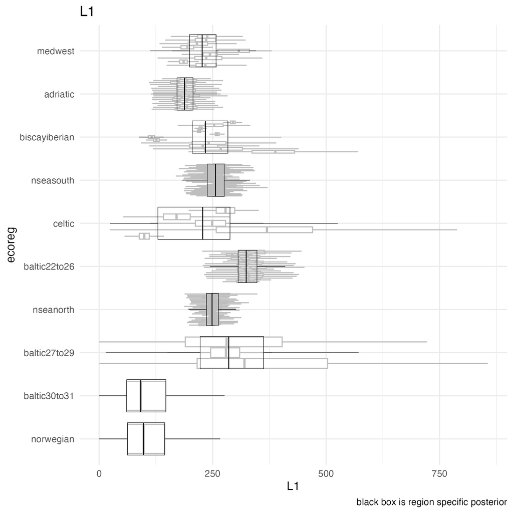

Figure 1: Posterior estimates of Schnute parameter $L_1$ ($\mu_{par}[1]$) by basin (grey lines) and region (black line).

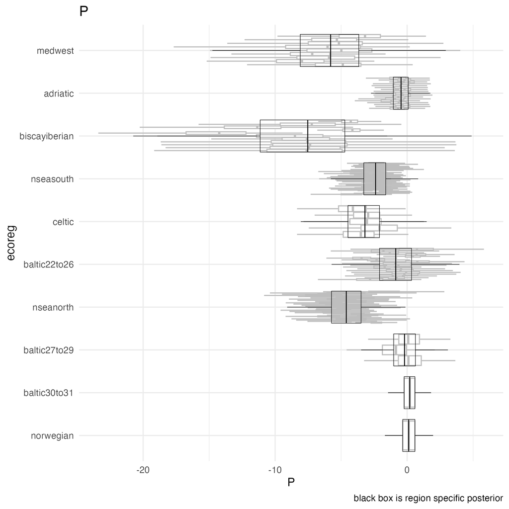

Figure 2: Posterior estimates of Schnute parameter $P$ ($\mu_{par}[2]$) by basin (grey lines) and region (black line).

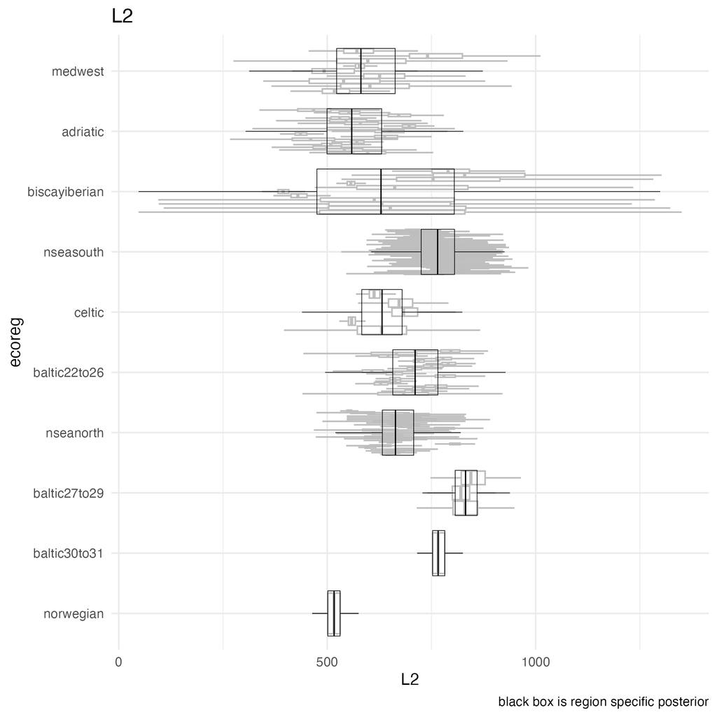

Figure 3: Posterior estimates by basin (grey lines) and region (black line) of Schnute parameter $L_2$ for females and mean temperature across regions (i.e. $\mu_{par}[3]$, see covariate effect $b_{sL}$ and $b_{tL}$ in Figure 8).

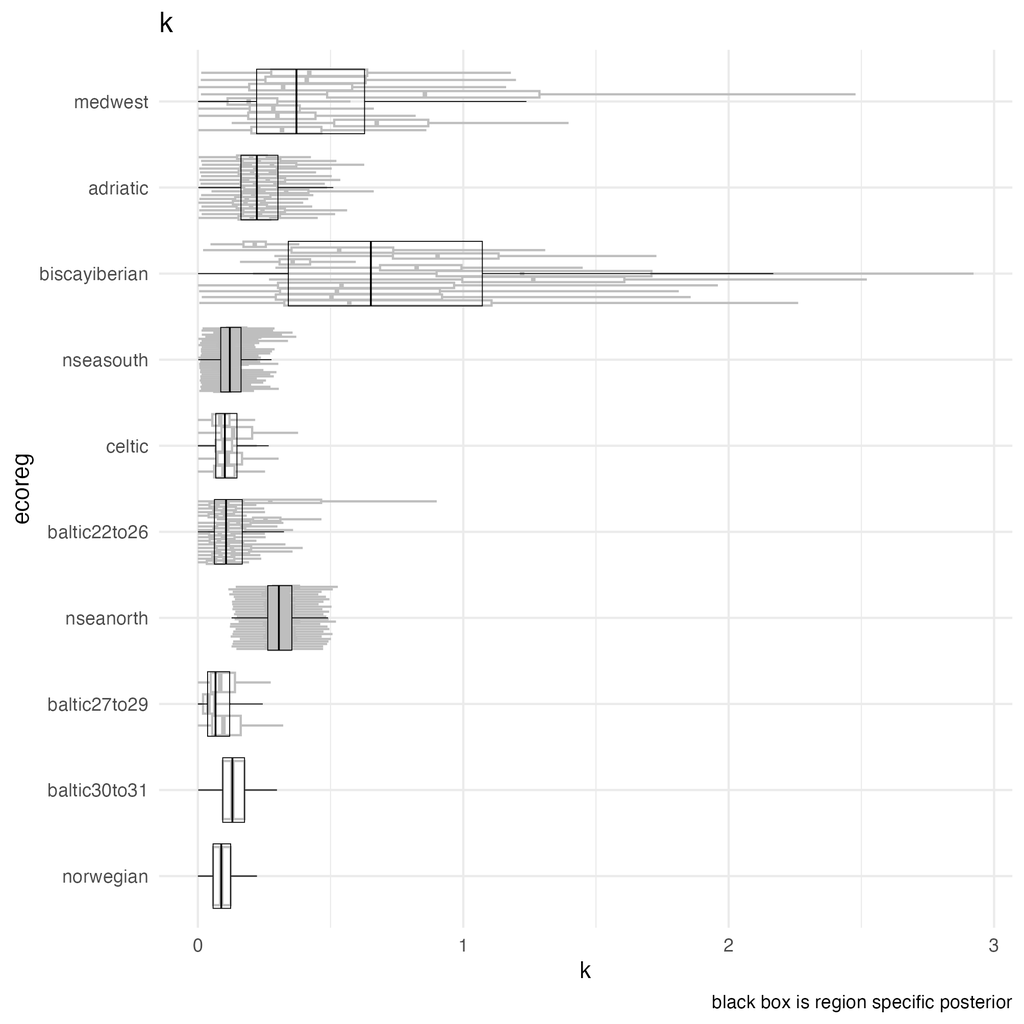

Figure 4: Posterior estimates by basin (grey lines) and region (black line) of Schnute parameter $k$ for females and mean temperature across regions and across habitats (i.e. $\mu_{par}[4]$, see covariate effect $b_{sk}$, $b_{tk}$ abd $h_k$ in Figure 8) .

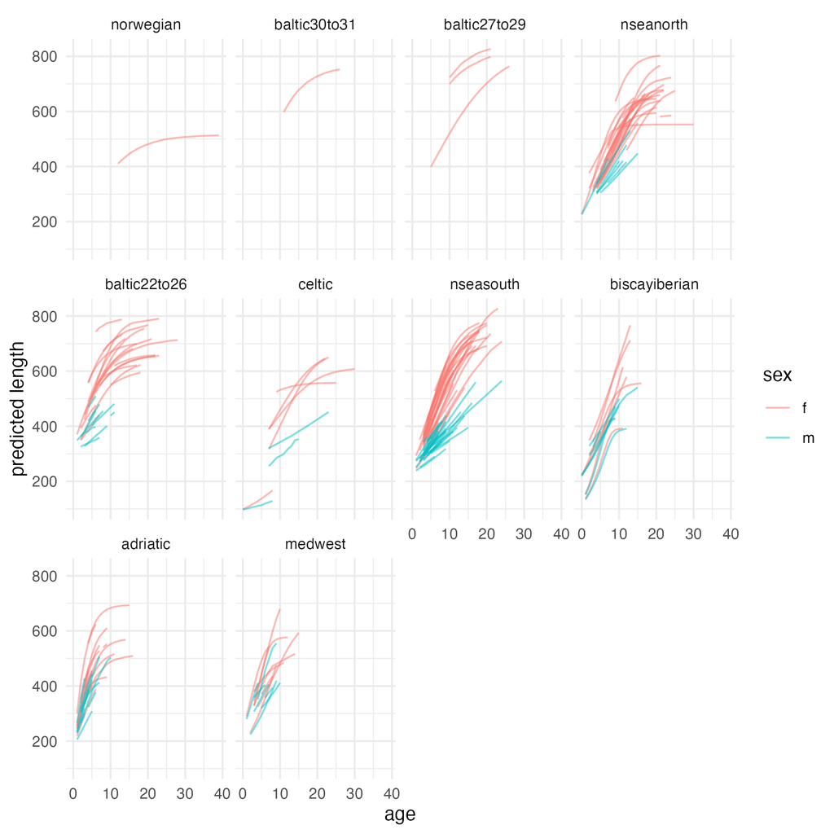

Figure 5: Basin specific growth curves by ecoregion and sex.

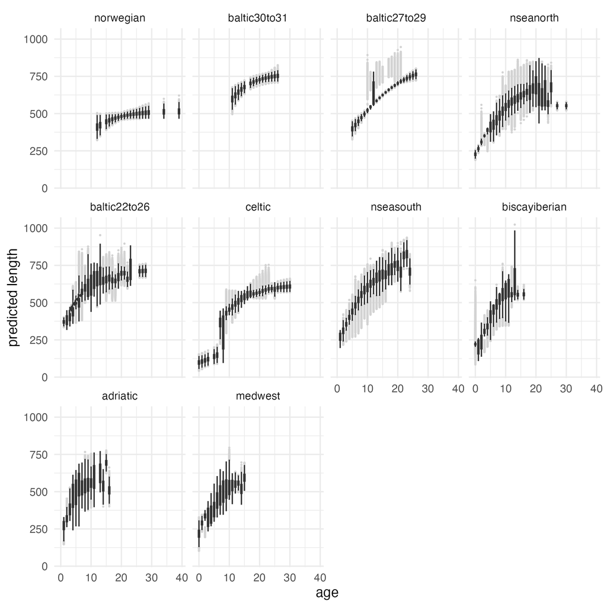

Figure 6: Posterior distributions of estimated female yellow eel length at age ($\mu_{L_i}$) by ecoregion. Boxplots summarise the posterior draws for each ecoregion and habitat where the center line is the median, boxes and whiskers show the IQR and 1.5 times IQR and grey points are outlier posterior draws. Note that the posteriors are summarised across river basins and that outliers often reflect river basins that are far from the average growth curve in the ecoregion.

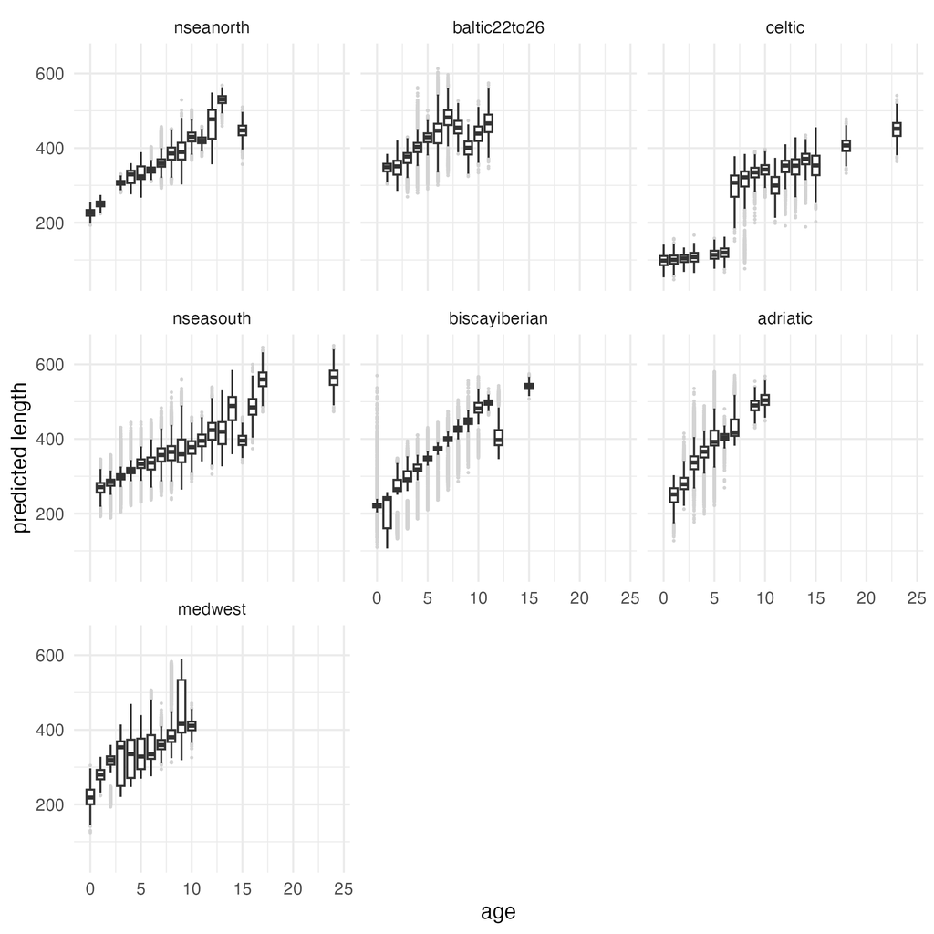

Figure 7: Posterior distributions of estimated male yellow eel length at age ($\mu_{L_i}$). Boxplots summarise the posterior draws for each ecoregion where the center line is the median, boxes and whiskers show the IQR and 1.5 times IQR and grey points are extreme posterior draws.

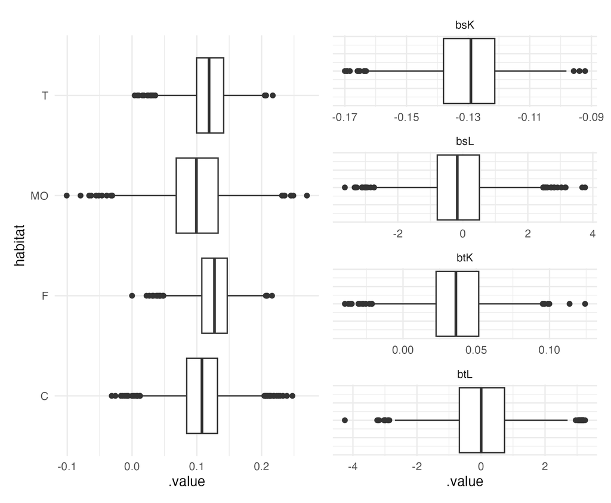

Figure 8: Posterior distributions of covariate parameters of the yellow eel length at age model. Right panel: the $b_s$ parameters are additive effect on $k$ $L_2$ estimated for males and the $b_t$ parameters are for temperature on $k$ $L_2$. Left panel: The effect of habitat type on $k$ (of habitats C = Coastal, F = Freshwater, T = Transitional and M = Marine open).

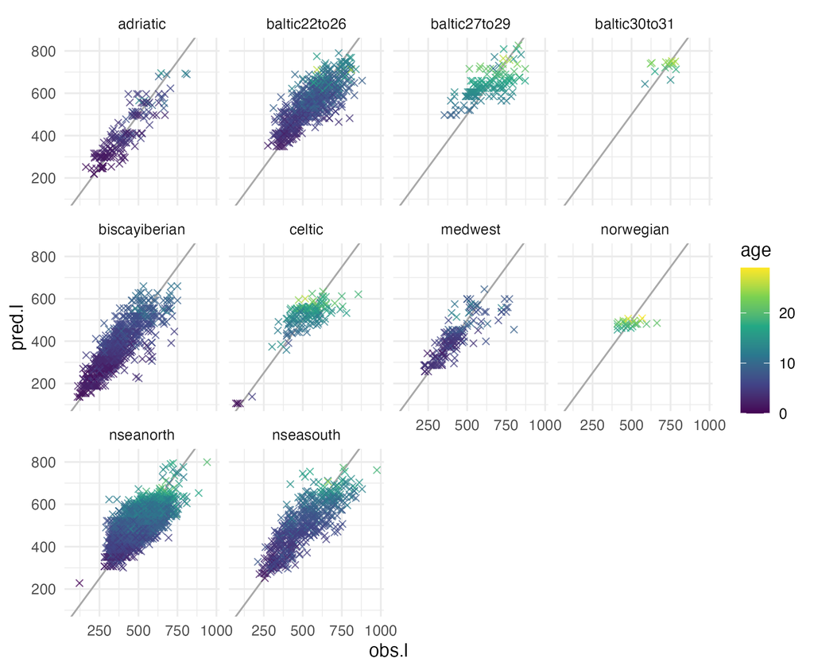

Figure 9: Observed $L_i$ and model predicted yellow eel length $\mu_{L_i}$ at age by ecoregion.

### Spatiotemporal variation in length at silvering

We modeled body length at silvering using hierarchical regression accounting for differences among ecoregions and temporal variation across years. Covariate effects of sex and region specific temperature were included in the model.

#### Data

Region specific temperature information from the HydroSHEDS database (Lehner, Verdin, and Jarvis 2008) was retrieved using the the DIASPARA habitat database (DIASPARA WP3) and was z-score scaled before use in the model.

#### Model description

We used a lognormal likelihood for $L_i$ of individual $i$ (i = 1,,n_{obs}) this was to capture positive values and right‑skewed variability (this choice was supported by comparing WAIC (Watanabe 2010) of a corresponding model based on a normal likelihood).

$L_i \sim \text{LogNormal}(\mu_{L_{[i]}}, \sigma_L)$

where $\mu_{L_i}$ is the expected log-length for individual $i$ and $\sigma_L$ is the residual standard deviation on the log scale. In turn, log-length is predicted by:

$\mu_{L_i} = \alpha_{j[i],year[i]} + b_{s,j}sex[i] + b_{T}T[i]$,

where $\alpha_{j,year}$ represents the intercept for region $j = 1,\dots,n_{j}$ in year $y$, $b_{s,j}$ is a region specific effect of sex, $b_t$ is the effect of temperature based on region specific mean temperature.

To account for temporal autocorrelation and spatial correlation, region specific intercepts were modeled as a multivariate random walk across years. Here, the intercepts in the first year were assigned a hierarchical prior to share information across regions,

$$\alpha_{j,1} \sim \text{Normal}(\mu_{\alpha,j},\, \sigma_{\alpha,j})$$
In subsequent years, the vector of intercepts follow a multivariate normal distribution

$$\boldsymbol{\alpha}_{i+1} \sim \text{MVN}(\boldsymbol{\alpha}_{i},\, \Sigma_\alpha),$$

where $\Sigma_\alpha$ is a covariance matrix describing correlation among regions. We used an LKJ prior (Lewandowski, Kurowicka, and Joe 2009) for the corresponding correlation matrix $R_\alpha$ to estimate correlations among regions. The covariance matrix relates to the correlation matrix by

$$\Sigma_\alpha = D R_\alpha D,$$

where $D$ is a diagonal matrix of region specific standard deviations $\sigma_{\alpha,j}$.

Hyperpriors for region specific intercept and standard deviations were

$$\mu_{\alpha,j} \sim \text{Normal}(\mu_{sl},\, \sigma_{sl}),$$

$$\sigma_{\alpha,j} \sim \text{Gamma}(1.5,8).$$

and we used a hierachical prior for a region specific covariate effect of sex,

$$b_{s,j} \sim \text{Normal}(\mu_{bs}, \sigma_{bs})$$

The hyperparameter values $\mu_{sl}, \sigma_{sl}, \mu_{bs}$ and $\sigma_{bs}$ are based on estimates of sex specific length at silvering in Durif, Dufour, and Elie (2005). The remaining parameters in the length at silvering model were assigned weakly informative priors (see Table 2).

Table 2: Prior distributions for parameters in the eel length at silvering model. (**Values are lognormal transformations of estimates in (2005)*)

[output not shown]

The model was implemented in NIMBLE, and posterior distributions of model parameters was estimated using Hamiltonian Monte Carlo sampling. Convergence was assessed by checking trace plots and Gelman–Rubin diagnostics (Gelman and Rubin 1992).

#### Results & Discussion

Calculated Gelman-Rubin statistics for all parameter estimates was below $1.03$. We used two chains with 1500 samples in each for convergence diagnostics (see Supplementary material model scripts and summaries for details on model formulation and diagnostics) and confirm that the MCMC chains had converged to a stationary distribution.

We estimated the median of the posterior of expected outcomes for length at silvering to 679 mm for females and 377 mm for males (the median parameter estimate for $\mu_{\alpha,j}$ is $582$). There is however large spatial variation with the smallest silvers eels in the Celtic sea (females) and the North Sea UK (males) and the largest silver eels in the Baltic ICES SD 27 to 29 (both sexes, Figure 11). The spatial correlations of mean silvering length $\boldsymbol{\alpha}$ (i.e. excluding covariate effects) is shown in Figure 14. Furthermore, the posterior distributions are heterogeneous across ecoregions suggesting that they are relevant for explaining differences in silvering length. The uncertainty of regional estimates vary however and further analysis could assess whether this is driven by variation in length, model structure or lack of data. Here, a model with river basins nested within region (as in the length at age model) might explain some of that variation.

For females, there is a tendency for an increase in length with latitude (Figure 11) as previously shown by Vøllestad (1992). Furthermore, our estimated median temperature effect ($b_T = -0.15)$) corresponding to a $5$% decrease in length per degree Celcius in our model. Temperature may therefore likely explain part of the latitudinal variation in the length at silvering in Figure 11. Plotting temperature (retrieved by river basin from Hydrosheds) against length in the data suggest that temperature effects may be sex specific (see Supplementary material model output summary) and this could be evaluated in future model development. Here, an analyses based on spatiotemporal rather than spatial temperature data, would probably better describe temperature and climate related effects on length at silvering.

Beyond sex dependent length, the model can be inaccurate in predictions (Figure 10). This demands a bit of care in conclusions drawn from the model output. The inaccuracy probably reflects that sizes later in life is particularly hard to predict, which was evident in the corresponding analysis for the eel length at age (Figure 9). Growth trajectories of eel and resulting length at maturity or age are variable and dependent on the environment, this is not surprising given the well known plasticity in eel length prior to spawning migration (Enbody et al. 2021; Vøllestad 1992). We prioritized with our model to describe spatiotemporal patterns in length at silvering across ecoregions and not placing priority of environmental predictors. This is obviously necessary for a good predictive model and to better asses spatiotemporal patterns and further work is needed for this task.

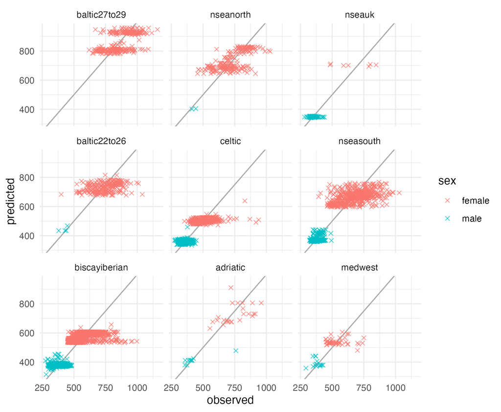

Figure 10: Observed and model predicted length at silvering by ecoregion.

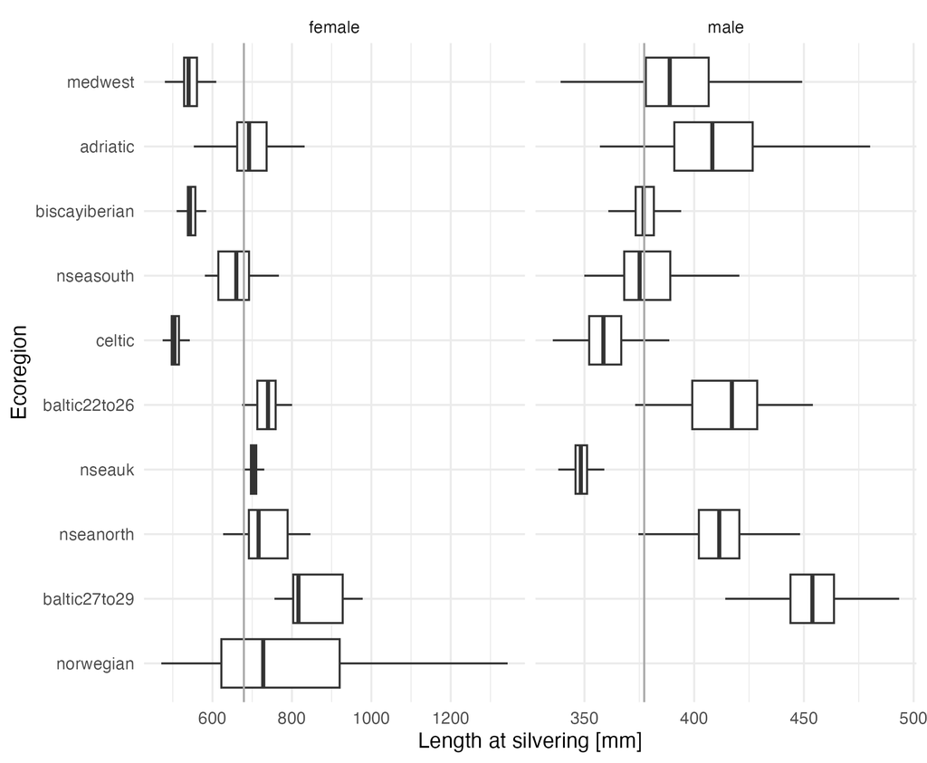

Figure 11: Predicted lengths ($\mu_{L_i}$) at silvering by ecoregion and sex. Boxes delimit the interquartile range of the posterior distributions of marginal predicted medians for each ecoregion and sex, whiskers extend beyond that range and outliers are excluded. The grey line is the median by sex.

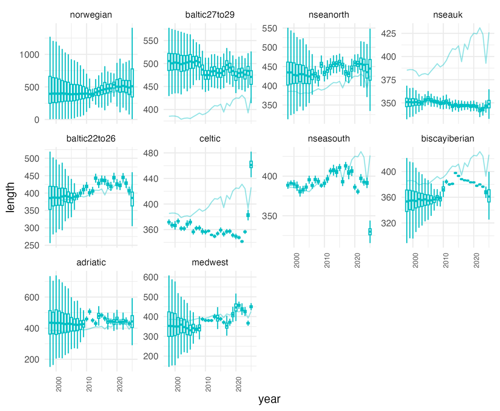

Figure 12: Male length at silvering (conditional predictions for mean observed temperature by region on $T = {\bar{T_j}}$) over time by ecoregion. Boxes delimit the interquartile range, whiskers extend beyond that range and outliers are excluded. The line shows the global male median by year. Note the different scales on the y-axis.

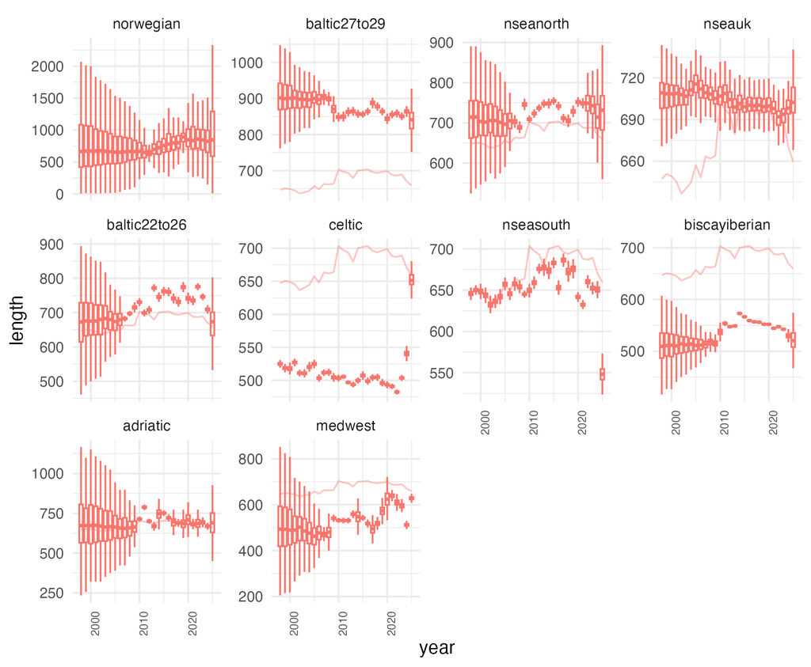

Figure 13: Female length at silvering (conditional predictions for mean observed temperature by region on $T = {\bar{T_j}}$) over time by ecoregion. Boxes delimit the interquartile range, whiskers extend beyond that range and outliers are excluded. The line shows the global female median by year. Note the different scales on the y-axis.

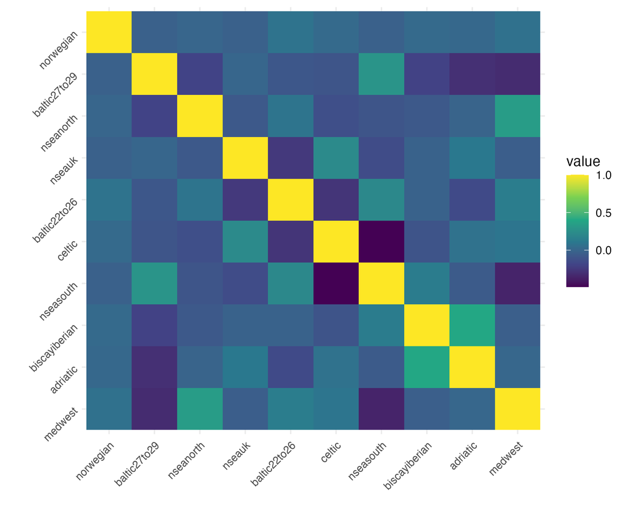

Figure 14: Correlation matrix $R$ describing correlations between length at silvering coefficient $\alpha_j$ for spatial units (ordered by latitude).

## Salmon

The spatial units for salmon were defined based on relevant scales for ecological, genetic and environmental processes and management areas but conditioned on data availability. For salmon, the spatial units correspond to assessment units (AU) for the Baltic Sea in which five out of six AU:s are represented in the data (AU 1-5) as well as a unit for Baltic salmon with unknown assessment unit (AU NA). For North Atlantic salmon, we used either the stock units from ICES’ assessment model (Sweden) or finer scale groupings: based on genetic analyses (France) (Perrier et al. 2011) or coastal areas (Ireland).

### Spatiotemporal variation in salmon length at age

We built a spatiotemporal model of individual body length as a function of age using a biphasic growth model. A biphasic growth model, separating life stages, is suitable for salmon as growth differ strongly between habitats (Nater et al. 2018). The model predicts age dependent length increments of cohorts recursively using a linear function for the freshwater (juvenile) phase and the von Bertalanffy growth function for the sea phase (Quince et al. 2008b).

The model estimates growth for each sex, cohort (birth year) and smolt age across spatial units and over time.

#### Data

We used data collected within the DIASPARA salmon data request on length data (total length in mm) on aged (in years) salmon individuals caught both in freshwater and at sea. Individual age estimates are based on counting growth rings (circuli) on scales and the age is separated into time spent in each habitat (freshwater and sea age) and separated by the age of at smoltification.

To account for seasonal variation in growth, a growth year ($age_g$) is consider as starting on May 1. Consequently, we assumed that all individuals are born on first of May and a growth year represents estimated age + 1 (e.g. $age_g$ of age 0 individuals equals 1).

The data included in the model comes from 12 spatial units: six in the Baltic sea (Assessment unit 1-5 and unknown (NA) assessment unit), the Swedish west coast, Brittany, lower Normandy, Adour, upper Normandy and the Irish west coast. We excluded non-aged individuals and individuals caught at sea and missing information of sex. This resulted in 79 559 individual observations for the model.

#### Model descritpion

##### Biphasic process model

We modeled expected increment in length at a given age to capture length $\mu_L$ at $age_g$ based on last years length across habitats and to predict growth rates for each year. We estimated length increments for each spatial unit $j$, smolt age $a$, cohort $c$, sex $s$, and growth year $age_g$. For the freshwater, linear growth phase, length for $age_g$ is predicted by

$$\mu_{L,j,a,c,s,age_g=1} = \mu_{L,j,a,c,s,age_g-1} + r_j$$
where $r_j$ is juvenile growth rate in $mm/y$. For the length at the first year of growth, $\mu_{L,j,a,c,s,age_g-1} = L_{b,j}$ representing the length at hatch.

$$\mu_{L,j,a,c,s,age_g} = L_{age_{g-1},j} + r_j$$
Growth in the sea phase is predicted by the Fabens (1965) version of the von Bertalanffy growth equation (with $\Delta t = 1$, i.e using yearly increments) which is suitable for modelling incremental data to predict expected length:

$$\mu_{L,j,a,c,s,age_g} = \mu_{L,j,a,c,s,age_g-1} + (L_{\infty,j,s} - \mu_{L,j,a,c,s,age_g-1})(1 - \exp(-k_{j,s,y}))$$
where $\mu_{L,j,a,c,s,age_g-1}$ is length in the last growth year $age_{g-1}$, $L_{\infty,j,s}$ is the spatial unit and sex-specific asymptotic length, $k_{j,s,y}$ is a year-specific von Bertalanffy growth coefficient where $y = c+age_g$. Smoltification at age $a$ delimits the two growth phases.

##### Observation models

We separated the observations by growth phase and used two observation models since the process model was built for fish carrying information on growth in both the age at smoltification and final age and for freshwater observations (parr and smolt), only the expected length predicted by linear growth is useful.

For salmon caught in their sea phase, observations i, length (total length in mm) was assumed to follow a normal distribution:

$L_{s,i} \sim \text{Normal}(\mu_{L_i,j[i],a[i],c[i],s[i],age_g[i]}, \sigma_{Ls})$

where $\mu_{L_i}$ is the expected length predicted by spatial unit (j), smolt age (a), cohort (c), sex (s), and growth year (age_g), and $\sigma_Ls$ is the residual observation error.

We used a normal likelihood also for the freshwater observations:

$L_{f,i} \sim \text{Normal}(mu_{Lj}, \sigma_{Lj})$

$\mu_{Lj} = L_{b,j[i]} + r_{j[i]}age_{g[i]}$

where $\sigma_{Lf}$ is the juvenile observation error.

##### Spatiotemporal process and priors

Parameters $L_{b,j}$, $r_j$ and $L_{\infty,j,s}$ were given estimates by spatial unit. The spatial unit specific estimates of the growth coefficient $k_{j,s,y}$ follows a multivariate random walk across years. The estimates in the first year were assigned a hierarchical prior to share information across regions:

$$k_{j,s,y=1} \sim \text{Normal}(\mu_{k,j}, \sigma_{k,j})$$
where $\mu_{k,j}$ and $\sigma_{k,j}$ are vectors of means and standard deviations by each spatial unit $j$. In years $y = 2, \dots, n_y$, the growth coefficient follow a multivariate normal distribution

$$\boldsymbol{k_{j,s,y}} \sim \text{MVN}(\boldsymbol{k_{j,s,y-1}},\, \Sigma_k),$$

where $\Sigma_k$ is a covariance matrix describing correlation among spatial units. We used an LKJ prior to estimate the corresponding correlation matrix $R_k$ of $\Sigma_k$. Here

$$\Sigma_k = D R_k D,$$

where $D$ is a diagonal matrix of region specific standard deviations in $\sigma_{k,j}$.

We used informative priors based on literature values (Fishbase Froese, R. and Pauly, D. (2025) and published studies) for $L_{\infty}, k,r$ and $L_b$ and weakly informative priors for the remaining parameters in the model (See table Table 3 for prior specifications).

Table 3: Prior distributions for parameters in the salmon length at age model. (**Values are estimated on log scale and are lognormal transformations of estimates from Fishbase (Froese, R. and Pauly, D. 2025)*.

| Parameter | Description | Prior distribution | Values |
| --- | --- | --- | --- |
| $\sigma_L$ | Sea length observation error SD | $\text{Exponential}(1/150)$ |  |
| $\sigma_{Lj}$ | Freshwater length observation error SD | $\text{Exponential}(1/20)$ |  |
| $L_{b,j}$ | Mean length at birth in $j$ | $\text{Uniform}(12, 20)$ | (Gilbey et al. 2009) |
| $r_j$ | Freshwater linear growth rate in $j$ | $\text{Normal}(\mu_r, 1)$ * | $\mu_r = 1.26$ ** |
| $L_{\infty,j,s}$ | Spatial unit and sex specific asymptotic length | $\text{Normal}(L_{\infty,\mu}, L_{\infty,sd})$ * | $L_{\infty,\mu} = 5.93$, $L_{\infty,sd} = 0.20$ ** |
| $k_{j,s, y=1}$ | Initial spatial unit- and sex specific mean growth coefficient | $\text{Normal}(k_{\mu}, 0.5)$ * | $k_{\mu} = -0.98$ ** |
| $\sigma_{k,j}$ | Spatial SD of growth coefficient variation | $\text{Lognormal}(\log(k_{\text{sd}}), 0.1)$ | $k_sd = 0.59$ |
| $\Sigma_p$ | Spatial covariance matrix for $k_{j,s,y}$ | $D,R_k,D$ |  |
| $R_k$ | Spatial correlation matrix for $k_{j,s,y}$ | $\text{LKJ}(\eta=2)$ |  |

The model was implemented in NIMBLE, and posterior distributions of model parameters was estimated using Hamiltonian Monte Carlo sampling. Convergence was assessed by checking trace plots and Gelman–Rubin diagnostics (Gelman and Rubin 1992).

#### Results & Discussion

Calculated Gelman-Rubin statistics for all parameter estimates was well below $1.1$. We used two chains with 1500 samples in each for convergence diagnostics (see Supplementary material model scripts and summaries for details on model formulation and diagnostics) and confirm that the MCMC chains had converged to a stationary distribution.

For the marine phase of our biphasic model of salmon length at age, the estimated global marginal parameter value for the growth coefficient $k$ is $0.47$ and length at infinity $L_\infty$ is $1042$. The lowest estimate of $k$ and highest of $L_\infty$ are found in the Baltic Sea AU2, the opposite (lowest $L_\infty$ and highest $k$) are found on the Irish west coast (Figure 15, Figure 16). However, the estimates of $k$ on the Irish west coast are extremely high and $L_\infty$ is likely too low (Figure 15, Figure 16). Conversely, $L_\infty$ for the Baltic Sea AU2 is extremely high, particularly for males (Figure 16). Possible causes for the poor estimates in Ireland are that there are few observations, little age dependent length variation and no old individuals in the data (mostly 1 and few 2 sea winters) causing issues in estimating von Bertalanffy parameters which are correlated (Pilling, Kirkwood, and Walker 2002). In case of the Baltic Sea AU2, there is many observations across ages and the accuracy of predicted values compared to observed are comparable to other regions (Figure 26). Possibly, observations here generate a relatively linear growth rate and does not cover the asymptotic growth phase. These issues could likely be resolved with a prior constraining variation of $L_\infty$.

For the freshwater phase, the estimated global marginal parameter value for the linear growth rate is $r = 46$ mm/year and size at hatching is $l_{b} = 20$ mm. While estimates of $r_j$ are spatially heterogeneous suggesting variable juvenile growth rates captured by our model (Figure 18), the parameter estimates for $l_{b}$ are all close $20$ mm (Figure 17). The prior for $l_b$ is bounded between $12$ and $20$ mm (Gilbey et al. 2009) but as $l_{b}$ is the intercept in the linear length at age and $r$ depends on $l_b$, this suggest that a more shallow curve could be estimated with a prior allowing values above 20 mm which is biologically implausible. The predictive ability of the model is lower for the freshwater phase Figure 25 than that for the marine Figure 26, underestimating size for small individuals and overestimating size for large individuals Figure 25. This supports that a more shallow linear curve would better estimate freshwater growth. This can be solved with a weaker prior with less biological meaning, or preferably a non-linear growth relationship allowing for higher growth rates early in the juvenile phase and lower prior to smolting. This would improve the model mechanistically and better represent growth patterns this life stage. Furthermore, regions with lower estimates and high uncertainty are likely implausible and here there is either no data (Adour and Baltic Sea AU-NA) or data is missing for some juvenile age groups (Baltic Sea AU1). A stricter hierarchical prior for $l_b$ would make estimates of $l_b$ more comparable and this can be reassessed when considering another functional form for juvenile growth rate.

The parameters $k, r$ and $L_\infty$ appear to follow an predictable latitudinal gradient. Growth rates $r$ and $k$ are higher in the south than in the north and for $L_\infty$, it is the opposite trend (Figure 18, Figure 15, Figure 16). While parameters of both a linear function and the von Bertalanffy growth function is correlated, this pattern reflects known gradients in fish growth over latitude and temperature (Heibo, Magnhagen, and Vøllestad 2005; Knouft 2004). Using this data set, further model development within DIASPARA will assess the influence of spatiotemporal variation in temperature and climate variables across life stages to improve knowledge on the role of climate change on salmon growth.

While the growth coefficient $k$ median across spatial units has varied over time (line in Figure 19 and Figure 19), regional trends are more distinct. In particular, $k$ is declining since the year 2000 in the North Atlantic (excluding males from Adour and females from the Swedish west coast). This spatial correlation in $k$ separating the North Atlantic and Baltic Sea is evident in Figure 27. The result of changes in $k$ over time in growth curves however suggest that small differences for cohorts within this time frame Figure 21. We assumed that $L_\infty$ varied by region and not over time and it is possible that dropping this assumption the model can better predict temporal variation in length at age. Whether this is possible using the current data set needs to be assessed.

Our model can predict length at age across smolt ages and cohorts and we could analyse the link between growth in the freshwater phase with growth in the marine phase (N. Jonsson and Jonsson 2007). There is possible spatial variation in the relationship between the smolt age and the first year of growth at sea (Figure 23,Figure 24) and such patterns earns further analysis. Importantly, we could assess whether such patterns are temporally consistent.

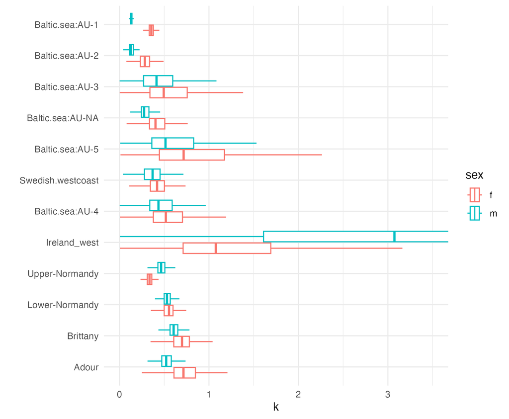

Figure 15: Salmon marine phase growth coefficient ($k$) over spatial units and by sex. Spatial units are ordered by their mean latitude. Boxes delimit the interquartile range, whiskers extend beyond that range and outliers are excluded.

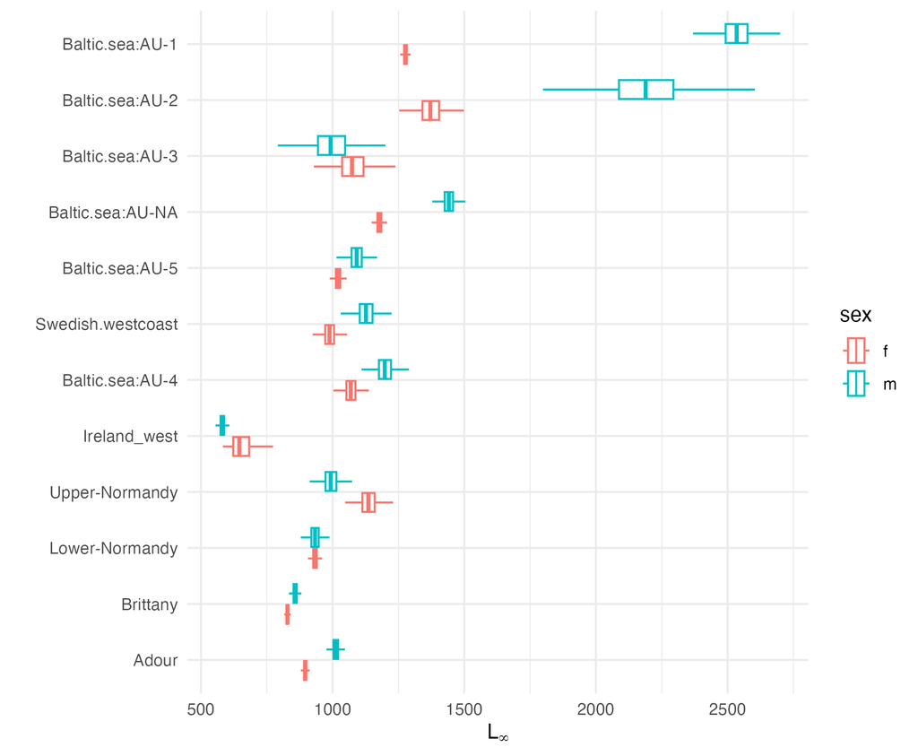

Figure 16: Salmon marine phase asymptotic length ($L_\infty$) over spatial units and by sex. Spatial units are ordered by their mean latitude. Boxes delimit the interquartile range, whiskers extend beyond that range and outliers are excluded.

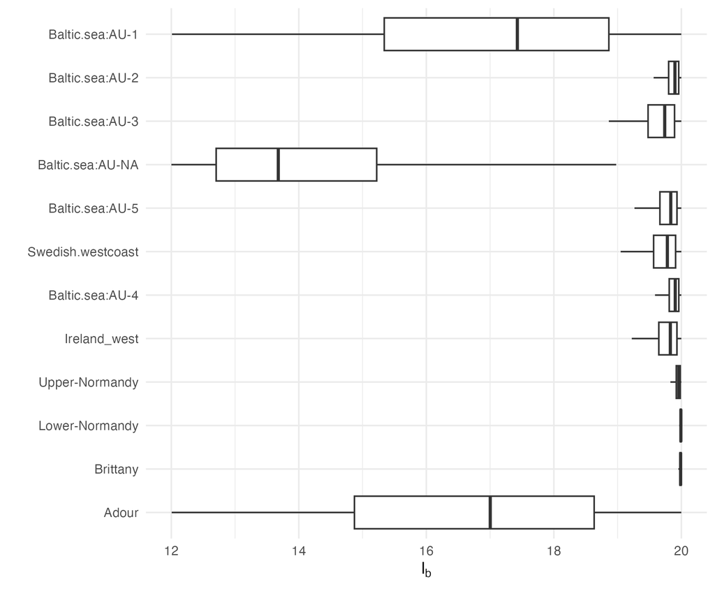

Figure 17: Salmon median length at hatching ($L_b$) over spatial units. Spatial units are ordered by their mean latitude. Note that spatial units Adour and Baltic Sea AU:NA lack freshwater observation data. Boxes delimit the interquartile range, whiskers extend beyond that range and outliers are excluded.

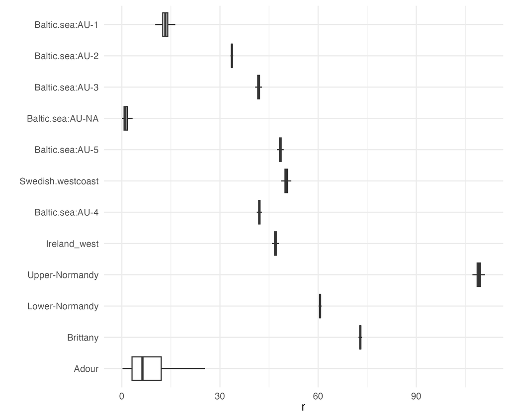

Figure 18: Salmon median freshwater linear growth rate ($r$) over spatial units. Boxes delimit the interquartile range, whiskers extend beyond that range and outliers are excluded. The spatial units are ordered by their mean latitude. Note that spatial units Adour and Baltic Sea AU:NA lack freshwater observation data.

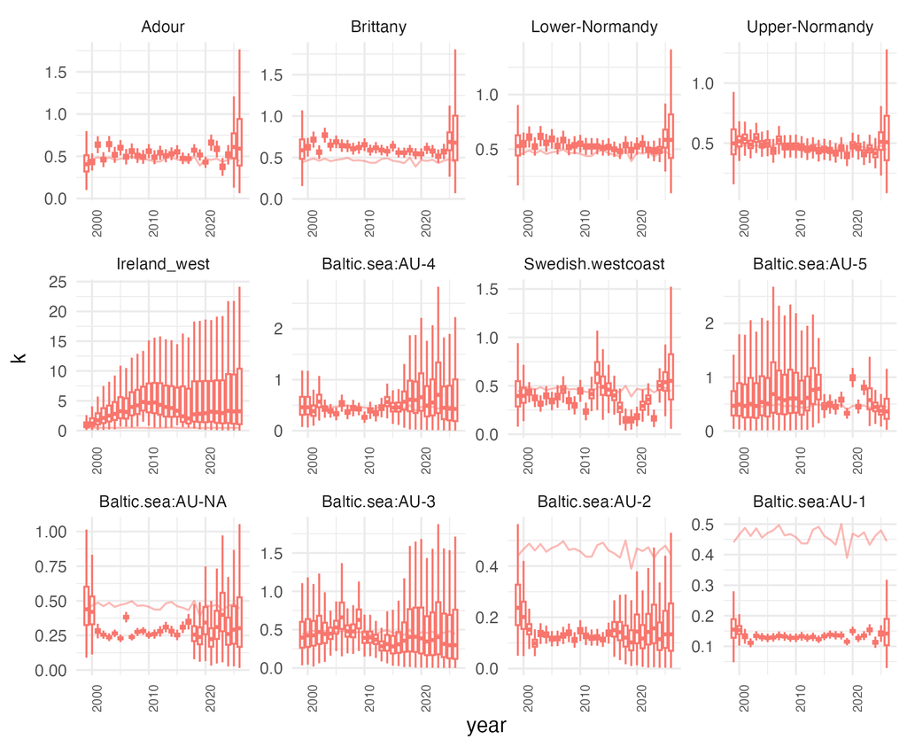

Figure 19: Salmon female growth coefficient ($k$) by spatial units over time. Boxes delimit the interquartile range, whiskers extend beyond that range and outliers are excluded. The line shows the median by year for females.

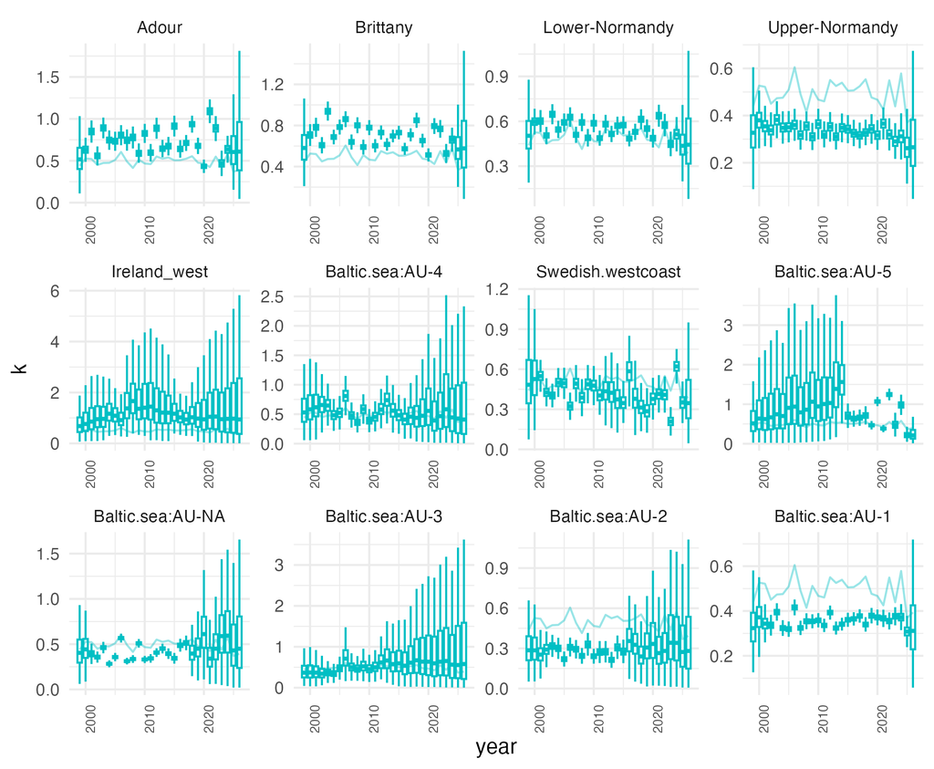

Figure 20: Salmon male growth coefficient ($k$) by spatial units over time. Boxes delimit the interquartile range, whiskers extend beyond that range and outliers are excluded. The line shows the median by year for males.

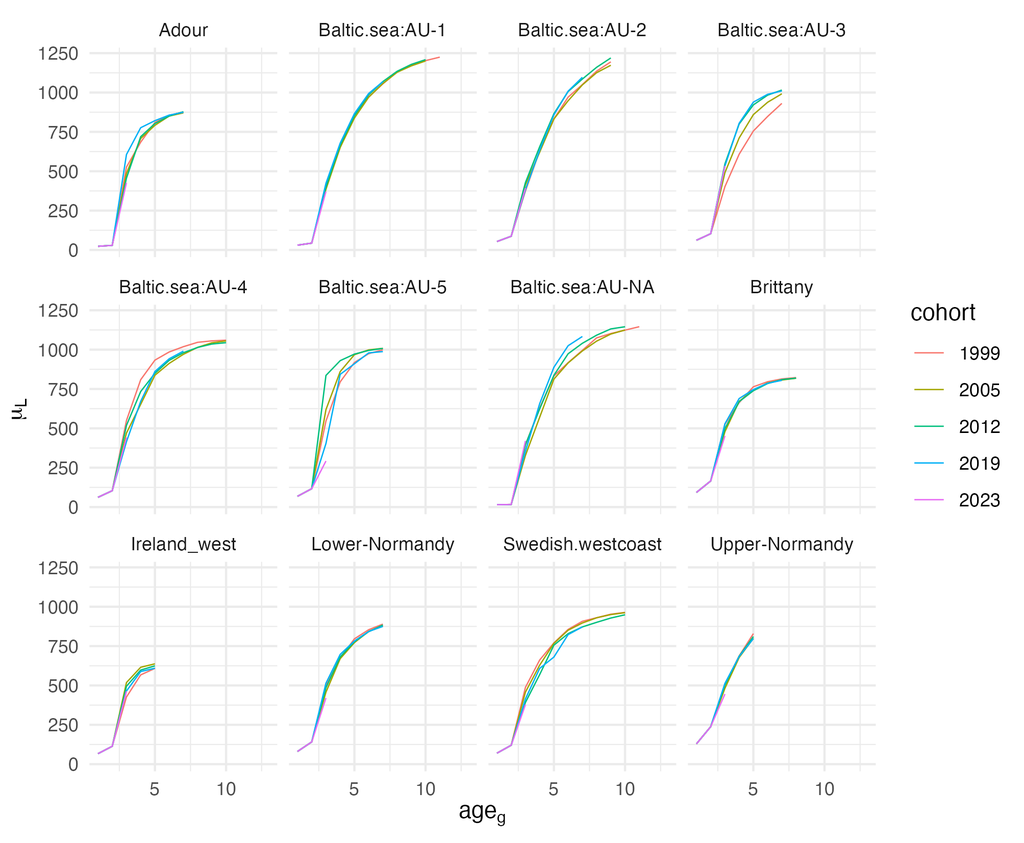

Figure 21: Predicted salmon female length at age ($\mu_{L,j,a,c,s,age_g}$) by spatial unit for five cohorts (colored scale) for two year old smolts. Boxes are spatial unit specific median estimates with interquartile range. Outliers are excluded.

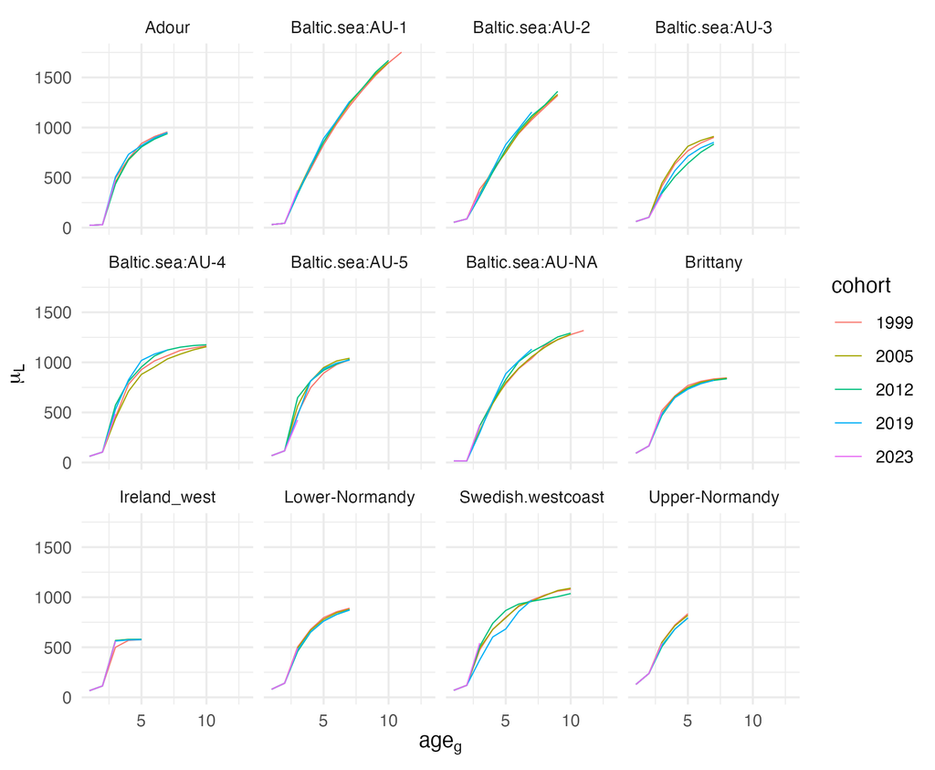

Figure 22: Predicted salmon male length at age ($\mu_{L,j,a,c,s,age_g}$) by spatial unit for five cohorts (color scale) for two year old smolts. Boxes are spatial unit specific median estimates with interquartile range. Outliers are excluded.

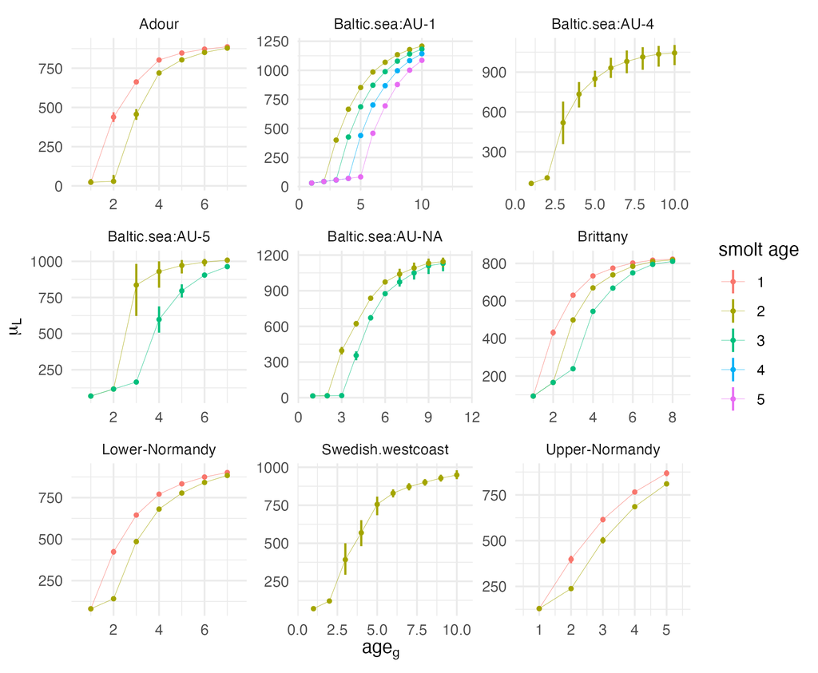

Figure 23: Predicted salmon female length at age ($\mu_{L,j,a,c,s,age_g}$) for salmon cohort 2012 by smolt age (color scale) and spatial unit. Boxes are spatial unit specific median estimates with interquartile range. Outliers are excluded. Note that both the different scales between spatial units and that predictions shown are for observed smolt ages and the maximum observed age for each spatial unit.

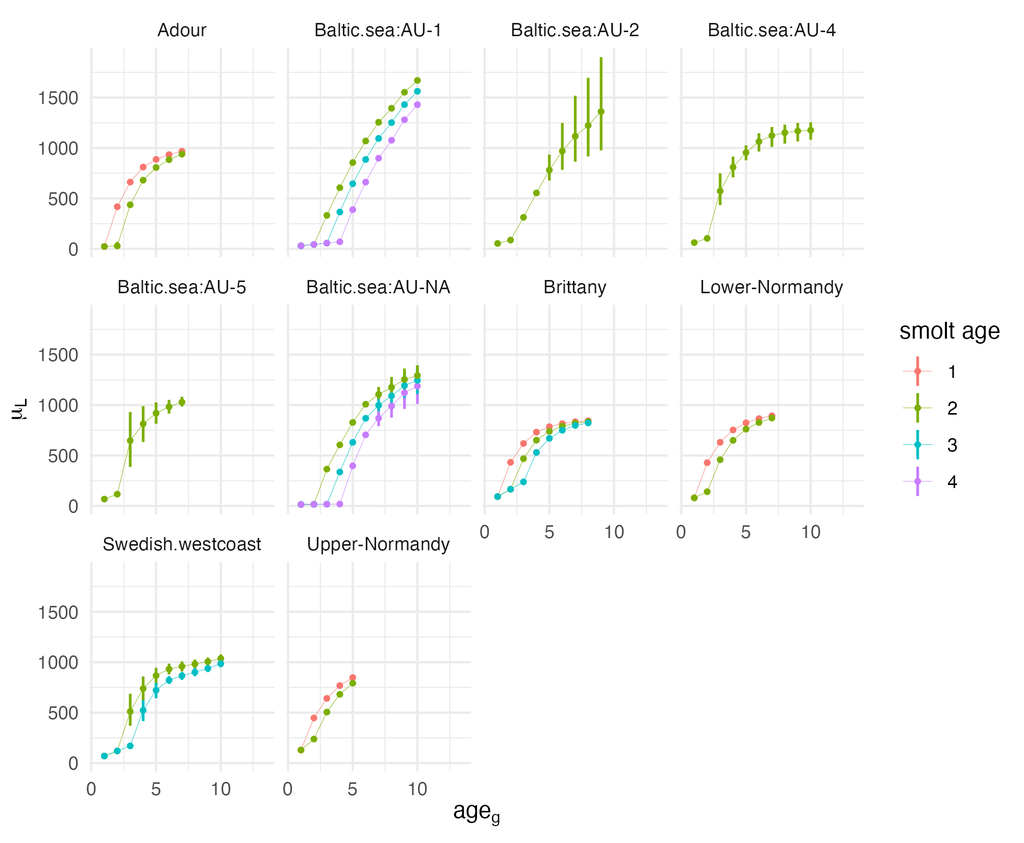

Figure 24: Predicted salmon male length at age ($\mu_{L,j,a,c,s,age_g}$) for salmon cohort 2012 by smolt age (color scale) and spatial unit. Boxes are spatial unit specific median estimates with interquartile range. Outliers are excluded. Note that both the different scales between spatial units and that predictions shown are for observed smolt ages and the maximum observed age for each spatial unit.

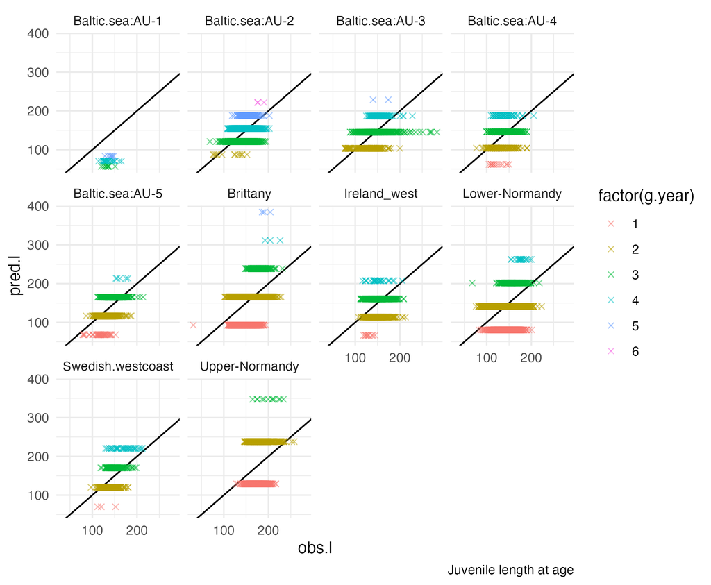

Figure 25: Observed and model predicted freshwater phase length at age by spatial unit.

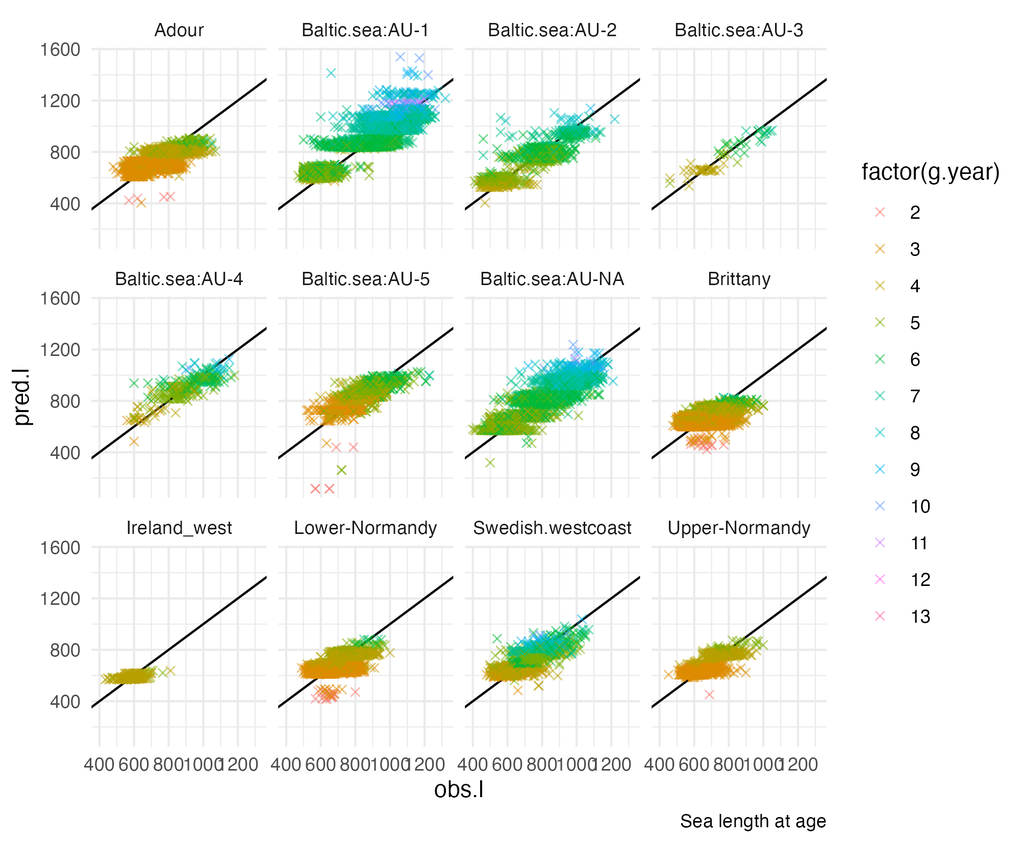

Figure 26: Observed and model predicted sea phase length at age by spatial unit.

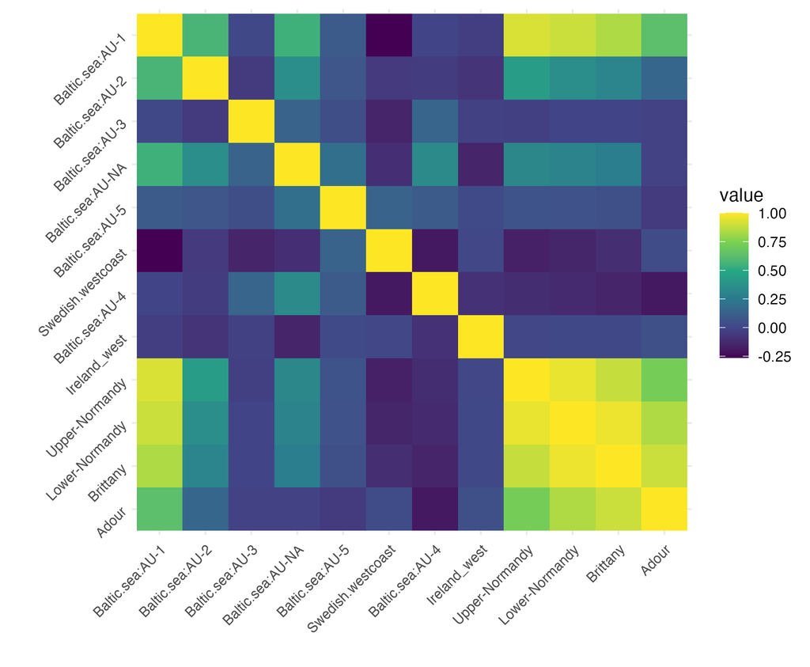

Figure 27: Correlation between growth coefficients $k$ for spatial units (ordered by latitude).

### Spatial variation in salmon fecundity

To describe spatial variation in fecundity, we developed a model of number of eggs per spawner given by length (fecundity at length). While e.g. age can be good predictors of fecundity (de Eyto et al. 2015), we used length as this was measured across all individuals in the data.

#### Model description

We assessed spatial variation in individual fecundity ($n.eggs$, egg count per spawner female) using a hierarchical negative binomial regression model to account for overdispersion.

$$n.eggs_i \sim \text{NegBin}(p_i, r)$$
where $r$ is the dispersion parameter and $p_i = r/(r+\mu_i)$. We assumed an allometric relationship $n.eggs =e^a \cdot L^b$} of individual body length $L$ and expected fecundity of individual $i$ ($\mu_i$) was modeled as a log–linear function:

$$log(\mu_i) = a_j + b_j \times \log\left(\frac{L_i}{\bar{L}}\right)$$

where $a_j$ and $b_j$ is intercept (fecundity at mean length on the log scale) and slope (multiplicative change in fecundity per unit length) of the length–fecundity relationship varying among spatial units $j = 1, \dots, n_{su}$ and $\log\left(\frac{L_i}{\bar{L}}\right)$ is mean centered log-length.

To share information across spatial units, intercepts ($a_j$) and slopes ($b_j$) were given hierarchical priors with hyperparameters specified for the group-level means ($\mu_a, \mu_b$) and standard deviations ($\sigma_b, \sigma_a$) (Table 4). Weakly informative priors were used for all parameters in the model (See table Table 4 for prior specifications).

The model was implemented in NIMBLE, and posterior distributions of model parameters was estimated using Hamiltonian Monte Carlo sampling. Convergence was assessed by checking trace plots and Gelman–Rubin diagnostics (Gelman and Rubin 1992) (see Supplementary material model scripts and summaries for details on model formulation and diagnostics).

Table 4: Prior distributions for parameters in the salmon fecundity model.

| Parameter | Description | Prior distribution |
| --- | --- | --- |
| $\text{n.eggs}_i$ | Number of eggs for individual $i$ | $\text{NegBin}(p_i, r)$ |
| $r$ | Negative binomial dispersion parameter | $\text{Gamma}(1, 1)$ |
| $a_j$ | Spatial unit specific intercept | $\text{Normal}(\mu_a, \sigma_a)$ |
| $b_j$ | Spatial unit specific slope | $\text{Normal}(\mu_b, \sigma_b)$ |
| $\mu_a$ | Mean intercept across spatial units | $\text{Normal}(0, 1)$ |
| $\sigma_a$ | SD of intercepts across spatial units | $\text{Exponential}(0.5)$ |
| $\mu_b$ | Mean slope across spatial units | $\text{Normal}(1, 1)$ |
| $\sigma_b$ | SD of slopes across spatial units | $\text{Exponential}(0.5)$ |

#### Results & Discussion

Calculated Gelman-Rubin statistics for all parameter estimates was below $1.01$. We used three chains with 2000 samples in each for convergence diagnostics (see Supplementary material model scripts and summaries for details on model formulation and diagnostics) and confirm that the MCMC chains had converged to a stationary distribution.

We estimated the posterior medians of the regression coefficients on the log-scale to $a = 8.90$ and $b = 2.52$ corresponding to $\log(n.eggs)$ for a salmon of mean length in our data (803 mm) and scaling with length by an exponent of $2.52$. There is considerable variation in the parameters between spatial units and the highest and lowest $a$ is found in the Baltic sea AU3 and Ireland west respectively and highest and lowest $b$ is found in lower Normandy and the Baltic sea AU3 (Figure 28). The spatial variation suggest there is more variation in intercept than in slope reflecting larger variation in absolute fecundity than in change in length. Furthermore, salmon from the Baltic Sea have consistently higher $a$ and lower $b$ than salmon from the Atlantic (Figure 28, Figure 28). For resulting fecundity at length on the log and natural scale, see Figure 29 and Figure 30.

Interpreting the result from the spatial estimates of $a$ and $b$ and resulting fecundity, should be done with care considering two key aspects. First, we did not account for the influence of method of extracting eggs from the fish in our model. The percentage of eggs left in the gonad after stripping in these fish varied between 0 and 51% with a mean of 6%. We have not assessed the effect of this variation in the current model as methodology varies spatially likely causing bias in spatial estimates but this needs to be evaluated. An alternative solution is to correct fecundity estimates a posteriori using the calculated percentage as an offset but preferably after consulting expertise on the specific data sets. Given a 6% increase in fecundity with this method, the Baltic sea would still have consistently higher fecundity than the North Atlantic salmon.

Second, the intercept ($a$) and slope ($b$) of the log-linear model appear correlated (Figure 28). While we took precaution to reduce that correlation by mean centering the linear predictor (log-length), we could improve the model by using a multivariate normal prior for $a$ and $b$.

Further improvements in the explanatory power of the model is adding biological predictors such as age, spawning history and body condition (de Eyto et al. (2015)), this requires information (e.g. age and weight) which is lacking for many data sets in the underlying data. Considering the obvious and possible improvements of our model and estimates the model is adequate in predictions (Figure 31) showing its applicability for use in assessment models. Here, combining the above spatiotemporal model of length at age with this model of fecundity at length to produce spatiotemporal estimates of fecundity at length will be produced within DIASPARA but are not reported here.

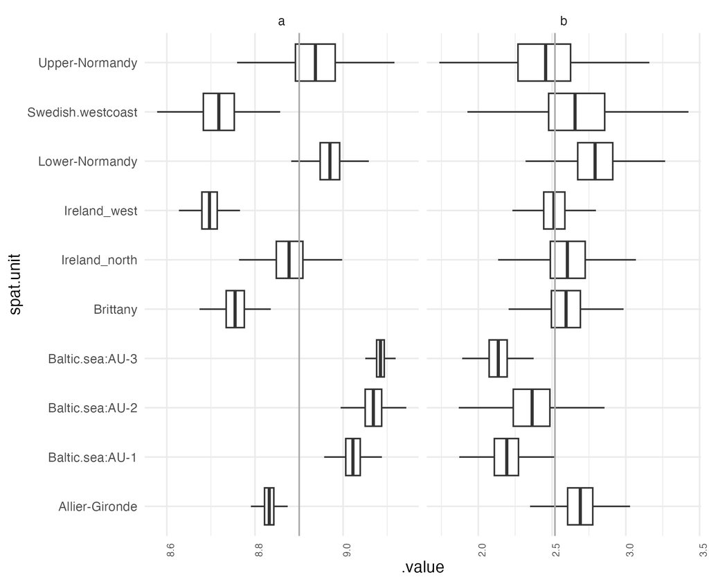

Figure 28: Estimates of $a$ and $b$ by spatial unit. Boxes shows the median and interquartile range, whiskers extend beyond that range and outliers are excluded. The grey line shows the overall median.

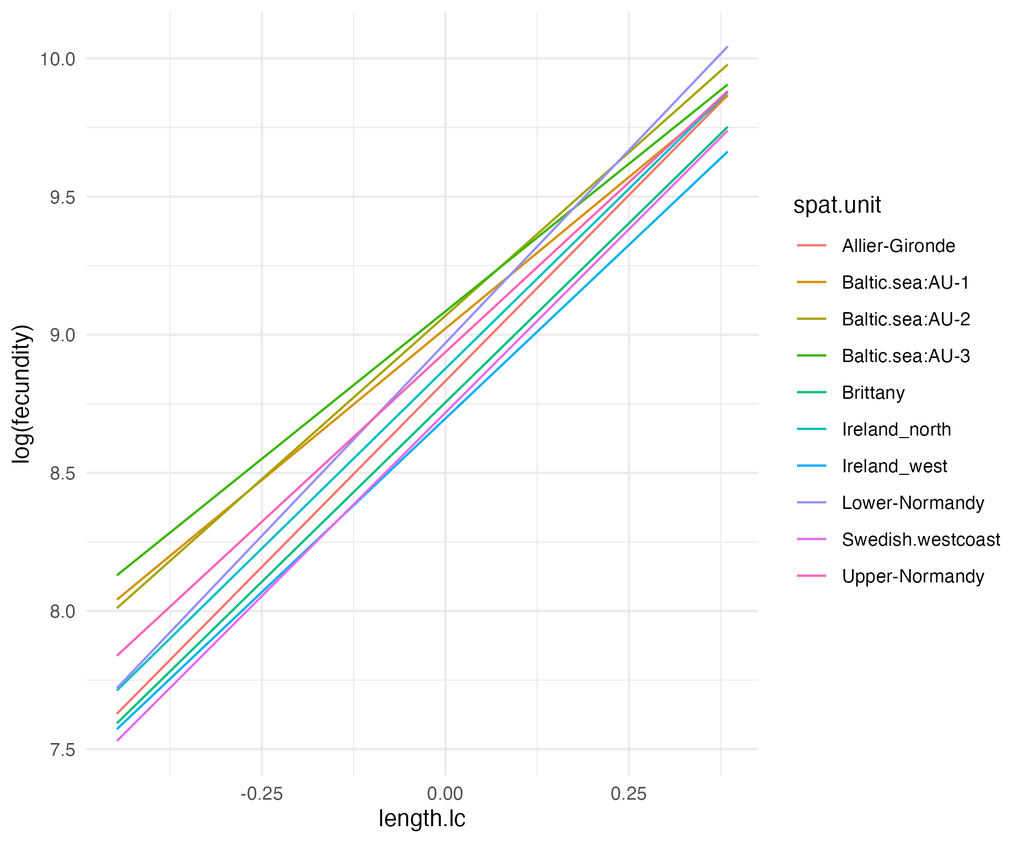

Figure 29: Log-linear fecundity at length by spatial unit where length.lc is mean centered log-length.

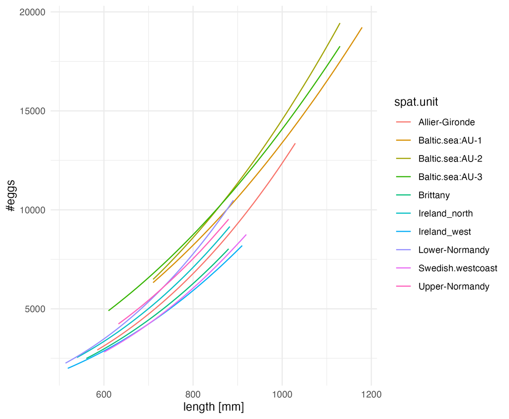

Figure 30: Estimated natural scale length dependent fecundity (number of eggs) by spatial unit.

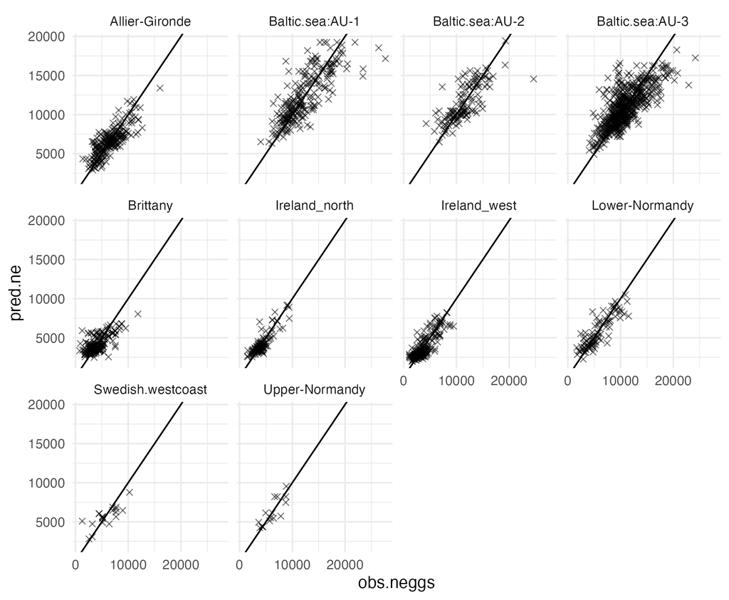

Figure 31: Observed and model predicted fecundity at length by spatial unit.

## Conclusions

The LHT models presented here are based on data identified within the project (DIASPARA task 2.1 Data inventory) and spatial information and environmental data for individual observations were retrieved from DIASPARA Habitat database (task 3.1). This showcases the utility of the different products of the DIASPARA work packages and a workflow for future model and data improvements. For example, the effect of hydrological information by river basin or river reach (elevation, flow regimes or distance to the sea) provided by the Habitat database should improve species and LHT specific estimates. This can improve knowledge of drivers of spatiotemporal variation in LHTs and management priorities based on those but also future data collection seeking suitable sampling strategies. This exemplifies how an ecosystem based approach to fisheries management can be operationalised.

To improve spatiotemporal estimates of salmon and eel life history traits we have highlighted data needs. Specifically we recommend data collection of 1) aged and sexed yellow eel to facilitate future spatiotemporal analyses of growth, 2) aged salmon juveniles to increase the spatiotemporal scope of the models, 3) salmon fecundity estimates based on common methodology to facilitate better estimate of spatial variation in fecundity. Ideally, an observation should contain length, weight, age, sex, coordinates and life stage of the individual fish. Overall, reoccurring and spatially explicit data collection on these variables will generally and largely improve the possibilities of describing spatiotemporal variation in LHT of both salmon and eel.

## Supplementary material

All model code and detailed summaries of model output are available at [https://github.com/DIASPARAproject/WP2_LHT/tree/main].

## References

Audzijonyte, Asta, Elizabeth Fulton, Malcolm Haddon, Fay Helidoniotis, Alistair J Hobday, Anna Kuparinen, John Morrongiello, Anthony DM Smith, Judy Upston, and Robin S Waples. 2016. “Trends and Management Implications of Human-Influenced Life-History Changes in Marine Ectotherms.” *Fish and Fisheries* 17 (4): 1005–28. https://doi.org/https://doi.org/10.1111/faf.12156.

Boulenger, Clarisse, Alain J. Crivelli, Fabien Charrier, Jean-Marc Roussel, Eric Feunteun, and Anthony Acou. 2016. “Difference in Factors Explaining Growth Rate Variability in European Eel Subpopulations: The Possible Role of Habitat Carrying Capacity.” *Ecology of Freshwater Fish* 25 (2): 281–94. https://doi.org/https://doi.org/10.1111/eff.12209.

Daverat, Françoise, Laurent Beaulaton, Russell Poole, Patrick Lambert, Håkan Wickström, Jan Andersson, Miran Aprahamian, et al. 2012. “One Century of Eel Growth: Changes and Implications.” *Ecology of Freshwater Fish* 21 (3): 325–36. https://doi.org/https://doi.org/10.1111/j.1600-0633.2011.00541.x.

de Eyto, E., J. White, P. Boylan, B. Clarke, D. Cotter, D. Doherty, P. Gargan, et al. 2015. “The Fecundity of Wild Irish Atlantic Salmon Salmo Salar l. And Its Application for Stock Assessment Purposes.” *Fisheries Research* 164: 159–69. https://doi.org/https://doi.org/10.1016/j.fishres.2014.11.017.

Drouineau, H., C. Briand, P. Lambert, and L. Beaulaton. 2016. “GEREM (Glass Eel Recruitment Estimation Model): A Model to Estimate Glass Eel Recruitment at Different Spatial Scales.” *Fisheries Research* 174: 68–80. https://doi.org/https://doi.org/10.1016/j.fishres.2015.09.003.

Drouineau, Hilaire, Caroline Durif, Martin Castonguay, Maria Mateo, Eric Rochard, Guy Verreault, Kazuki Yokouchi, and Patrick Lambert. 2018. “Freshwater Eels: A Symbol of the Effects of Global Change.” *Fish and Fisheries* 19 (5): 903–30. https://doi.org/https://doi.org/10.1111/faf.12300.

Durif, C., S. Dufour, and P. Elie. 2005. “The Silvering Process of Anguilla Anguilla: A New Classification from the Yellow Resident to the Silver Migrating Stage.” *Journal of Fish Biology* 66 (4): 1025–43. https://doi.org/https://doi.org/10.1111/j.0022-1112.2005.00662.x.

Enbody, Erik D., Mats E. Pettersson, C. Grace Sprehn, Stefan Palm, Håkan Wickström, and Leif Andersson. 2021. “Ecological Adaptation in European Eels Is Based on Phenotypic Plasticity.” *Proceedings of the National Academy of Sciences* 118 (4): e2022620118. https://doi.org/10.1073/pnas.2022620118.

Fabens, A. J. 1965. “Properties and Fitting of the von Bertalanffy Growth Curve.” *Growth* 29: 265–89.

Frissell, Christopher A., William J. Liss, Charles E. Warren, and Michael D. Hurley. 1986. “A Hierarchical Framework for Stream Habitat Classification: Viewing Streams in a Watershed Context.” *Environmental Management* 10 (2): 199–214. https://doi.org/10.1007/BF01867358.

Froese, R., and Pauly, D. 2025. “FishBase.” World Wide Web electronic publication. https://www.fishbase.org.

Gelman, Andrew, and Donald B. Rubin. 1992. “Inference from Iterative Simulation Using Multiple Sequences.” *Statistical Science* 7 (4): 457–72. https://doi.org/10.1214/ss/1177011136.

Gilbey, J., E. Cauwelier, C. S. Jones, A. Mclay, L. R. Noble, and E. Verspoor. 2009. “Size-Dependent Growth of Individual Atlantic Salmon Salmo Salar Alevins from Hatch to First Feeding.” *Journal of Fish Biology* 75 (10): 2820–31. https://doi.org/https://doi.org/10.1111/j.1095-8649.2009.02497.x.

Ginneken, Vincent J. T. van, and Gregory E. Maes. 2005. “The European Eel (Anguilla Anguilla, Linnaeus), Its Lifecycle, Evolution and Reproduction: A Literature Review.” *Reviews in Fish Biology and Fisheries* 15 (4): 367–98. https://doi.org/10.1007/s11160-006-0005-8.

Heibo, Erik, Carin Magnhagen, and Leif Asbjørn Vøllestad. 2005. “LATITUDINAL VARIATION IN LIFE-HISTORY TRAITS IN EURASIAN PERCH.” *Ecology* 86 (12): 3377–86. https://doi.org/https://doi.org/10.1890/04-1620.

Hutchings, Jeffrey A, and Megan EB Jones. 1998. “Life History Variation and Growth Rate Thresholds for Maturity in Atlantic Salmon, Salmo Salar.” *Canadian Journal of Fisheries and Aquatic Sciences* 55 (S1): 22–47. https://doi.org/10.1139/d98-004.

ICES. 2025a. “Baltic Salmon and Trout Assessment Working Group (WGBAST),” May. https://doi.org/10.17895/ices.pub.29118545.v2.

———. 2025b. “Working Group on North Atlantic Salmon (WGNAS),” May. https://doi.org/10.17895/ices.pub.28777226.v1.

Jonsson, Bror, and Nina Jonsson. 2017. “Fecundity and Water Flow Influence the Dynamics of Atlantic Salmon.” *Ecology of Freshwater Fish* 26 (3): 497–502. https://doi.org/https://doi.org/10.1111/eff.12294.

Jonsson, N., and B. Jonsson. 2007. “Sea Growth, Smolt Age and Age at Sexual Maturation in Atlantic Salmon.” *Journal of Fish Biology* 71 (1): 245–52. https://doi.org/https://doi.org/10.1111/j.1095-8649.2007.01488.x.

Karlsson, L., and Ö. Karlström. 1994. “The Baltic Salmon (Salmo Salar l.): Its History, Present Situation and Future.” *Dana* 10: 61–85.

Kettle, A. James, L. Asbjørn Vøllestad, and Joanna Wibig. 2011. “Where Once the Eel and the Elephant Were Together: Decline of the European Eel Because of Changing Hydrology in Southwest Europe and Northwest Africa?” *Fish and Fisheries* 12 (4): 380–411. https://doi.org/https://doi.org/10.1111/j.1467-2979.2010.00400.x.

Klemetsen, A., P.-A. Amundsen, J. B. Dempson, B. Jonsson, N. Jonsson, M. F. O’Connell, and E. Mortensen. 2003. “Atlantic Salmon Salmo Salar l., Brown Trout Salmo Trutta l. And Arctic Charr Salvelinus Alpinus (l.): A Review of Aspects of Their Life Histories.” *Ecology of Freshwater Fish* 12 (1): 1–59. https://doi.org/https://doi.org/10.1034/j.1600-0633.2003.00010.x.

Knouft, Jason H. 2004. “Latitudinal Variation in the Shape of the Species Body Size Distribution: An Analysis Using Freshwater Fishes.” *Oecologia* 139 (3): 408–17. https://doi.org/10.1007/s00442-004-1510-x.

Kozlowski, Jan. 1999. “Adaptation: A Life History Perspective.” *Oikos* 86: 185–94. https://doi.org/10.2307/3546437.

Lehner, B., K. Verdin, and A. Jarvis. 2008. “New Global Hydrography Derived from Spaceborne Elevation Data.” *Eos, Transactions, American Geophysical Union* 89 (10): 93–94. https://doi.org/10.1029/2008EO100001.

Lewandowski, Daniel, Dorota Kurowicka, and Harry Joe. 2009. “Generating Random Correlation Matrices Based on Vines and Extended Onion Method.” *Journal of Multivariate Analysis* 100 (9): 1989–2001. https://doi.org/https://doi.org/10.1016/j.jmva.2009.04.008.

MacNamara, Ruairí, T. Kieran McCarthy, Håkan Wickström, and Patrik D. Clevestam. 2015. “Fecundity of Silver-Phase Eels (Anguilla Anguilla) from Different Habitat Types and Geographic Locations.” *ICES Journal of Marine Science* 73 (1): 135–41. https://doi.org/10.1093/icesjms/fsv065.

Moll, Dorothee, Harald Asmus, Alexandra Blöcker, Uwe Böttcher, Jan Conradt, Leonie Färber, Nicole Funk, et al. 2024. “A Climate Vulnerability Assessment of the Fish Community in the Western Baltic Sea.” *Scientific Reports* 14: 16184. https://doi.org/10.1038/s41598-024-67029-2.

Nater, Chloé R., Atle Rustadbakken, Torbjørn Ergon, Øystein Langangen, S. Jannicke Moe, Yngvild Vindenes, Leif Asbjørn Vøllestad, and Per Aass. 2018. “Individual Heterogeneity and Early Life Conditions Shape Growth in a Freshwater Top Predator.” *Ecology* 99 (5): 1011–17. https://doi.org/https://doi.org/10.1002/ecy.2178.

Perrier, Charles, René Guyomard, Jean-Luc Bagliniere, and Guillaume Evanno. 2011. “Determinants of Hierarchical Genetic Structure in Atlantic Salmon Populations: Environmental Factors Vs. Anthropogenic Influences.” *Molecular Ecology* 20 (20): 4231–45. https://doi.org/https://doi.org/10.1111/j.1365-294X.2011.05266.x.

Pilling, Graham M, Geoffrey P Kirkwood, and Stephen G Walker. 2002. “An Improved Method for Estimating Individual Growth Variability in Fish, and the Correlation Between von Bertalanffy Growth Parameters.” *Canadian Journal of Fisheries and Aquatic Sciences* 59 (3): 424–32. https://doi.org/10.1139/f02-022.

Quince, Christopher, Peter A. Abrams, Brian J. Shuter, and Nigel P. Lester. 2008b. “Biphasic Growth in Fish i: Theoretical Foundations.” *Journal of Theoretical Biology* 254 (2): 197–206. https://doi.org/https://doi.org/10.1016/j.jtbi.2008.05.029.

———. 2008a. “Biphasic Growth in Fish i: Theoretical Foundations.” *Journal of Theoretical Biology* 254 (2): 197–206. https://doi.org/https://doi.org/10.1016/j.jtbi.2008.05.029.

Reid, Jenny E., and Gérald Chaput. 2012. “Spawning History Influence on Fecundity, Egg Size, and Egg Survival of Atlantic Salmon (Salmo Salar) from the Miramichi River, New Brunswick, Canada.” *ICES Journal of Marine Science* 69 (9): 1678–85. https://doi.org/10.1093/icesjms/fss091.

Schnute, Jon. 1981. “A Versatile Growth Model with Statistically Stable Parameters.” *Canadian Journal of Fisheries and Aquatic Sciences* 38 (9): 1128–40. https://doi.org/10.1139/f81-153.

Stuber, Erica F., and Lutz F. Gruber. 2020. “Recent Methodological Solutions to Identifying Scales of Effect in Multi-Scale Modeling.” *Current Landscape Ecology Reports* 5 (4): 127–39. https://doi.org/10.1007/s40823-020-00055-8.

Vøllestad, Leif Asbjørn. 1992. “Geographic Variation in Age and Length at Metamorphosis of Maturing European Eel: Environmental Effects and Phenotypic Plasticity.” *Journal of Animal Ecology* 61 (1): 41–48. https://doi.org/10.2307/5507.

Watanabe, Sumio. 2010. “Asymptotic Equivalence of Bayes Cross Validation and Widely Applicable Information Criterion in Singular Learning Theory.” *Journal of Machine Learning Research* 11: 3571–94.

EU is not reponsible for the content of the project